# RTMS Timer Data Mining

Leonardo Ji

2017-05-13

```r
knitr::opts_chunk$set(echo = TRUE)
options(scipen=999)
library(ggplot2)
library(scales)
library(tidyverse)
library(cluster)
library(arules)
library(dplyr)
library(splitstackshape)
library(arulesViz)
library(fpc)
library(clusterSim)
library(stats)
library(rpart)
library(rpart.plot)
library(party)
library(partykit)
library(caret)
library(VIM)
library(randomForest)
library(e1071)
library(ROCR)
library(knitr)
```

## Background information

My data set is a RTMS (Response Time Measurement System) timer data from a health care software solution. The RTMS timer data was produced from actual user interacting with software user interface when background service collect data at real time. User timer measures actual the response time. This is also the time between user click on a button sends a request until the response come back. Each timer also contains additional information from a single transaction such as timer name, domain name, application name, user name, node name, end date time.

## Why

Using timer data, I want to understand the following questions:

- What is this software’s user profile groups?
- What is the typical workflow? Find strong rules such as user action 1 leads to user action 2.
- What are reasons causing system slow response time?

These questions would help software developers to understand actual user profiles and workflows, improve user experiences.

## Data

```r
timer <- read.csv("C:/Users/lj015625/Desktop/DataMining Class/Final/Data/Timer_04-24-2017.csv")
dim(timer)
```

```
## [1] 1000000      24
```

```r
str(timer)
```

```
## 'data.frame':    1000000 obs. of  24 variables:
##  $ CLIENT          : Factor w/ 125 levels "ADHA_AE","ADVN_MD",..: 113 113 75 113 114 75 113 113 101 60 ...
##  $ DOMAIN          : Factor w/ 222 levels "1501DEP","1501ENG",..: 202 202 182 202 202 182 202 202 124 176 ...
##  $ ENTERPRISE      : Factor w/ 121 levels "ADVN_MD","AGNE_WI",..: 73 73 74 73 94 74 73 73 100 58 ...
##  $ ELAPSEDTIME     : num  0.000154 0.682106 0.1069 0.270366 0 ...
##  $ TIMERNAME       : Factor w/ 75 levels "CAP:MPG.RCM.POST-ACUTE-CURASPAN",..: 4 48 71 71 10 71 4 71 71 71 ...
##  $ PROPERTYVALUES  : Factor w/ 235 levels "",",",",BUSINESS SEARCH",..: 230 1 1 1 1 1 230 1 1 1 ...
##  $ FRAMEWORKVERSION: int  4 4 4 4 3 4 4 4 4 4 ...
##  $ ENDDATETIME     : Factor w/ 143394 levels "16-Apr-2017 00:00:00",..: 1 1 1 1 2 3 4 5 6 7 ...
##  $ CLIENTIP        : Factor w/ 15236 levels "0.0.0.0","1.1.5.169",..: 6159 6614 2479 6159 6270 9211 9623 9623 1 1768 ...
##  $ USERPRINCIPALS  : Factor w/ 11375 levels "001161","001338",..: 3273 4794 1112 3273 2989 11079 6430 6430 7119 6319 ...
##  $ NODENAME        : Factor w/ 5563 levels "ADHAAECTX331",..: 5135 5188 3297 5135 5330 3312 5098 5098 4612 2557 ...
##  $ NODEIP          : Factor w/ 4456 levels "0.0.0.0","10.0.75.1",..: 1642 1538 2946 1642 1 2933 1605 1605 680 3477 ...
##  $ CLIENTNAME      : Factor w/ 14773 levels "","0010E031C72E",..: 1564 11744 7393 1564 13574 2574 1622 1622 7141 4771 ...
##  $ APPLICATIONNAME : Factor w/ 5 levels "DISCERNVISUALDEVELOPER",..: 2 2 3 2 3 3 2 2 3 3 ...
##  $ VERSION         : int  4 6 7 7 0 7 4 7 7 7 ...
##  $ METADATA1       : Factor w/ 58 levels "","url=http://10.190.228.174/caremanagement-service-war/surround.northamerica.cerner.net/service/surround.northamerica.cerner.net/"| __truncated__,..: 1 1 1 1 1 1 1 1 1 1 ...
##  $ METADATA2       : Factor w/ 315 levels "","context={\"component\":\"\"}",..: 1 1 1 1 1 1 1 1 1 1 ...
##  $ METADATA3       : logi  NA NA NA NA NA NA ...
##  $ RESULTCOUNT     : int  0 0 0 0 0 0 0 0 0 0 ...
##  $ PROCESSID       : Factor w/ 15018 levels "10000","100032",..: 2312 10194 14963 2312 324 6657 3944 3944 1727 6206 ...
##  $ THREADID        : int  22900 2372 24872 22900 89492 8520 12140 12140 25412 15736 ...
##  $ START_OFFSET    : num  3697854956700 24696139719500 3537527107700 3698163683800 5024625232885 ...
##  $ STOP_OFFSET     : num  3697855111200 24696821825100 3537634008200 3698434049400 5024625588168 ...
##  $ TIMER_ID        : num  2343579848800 2343579816103 2343561011266 2343579098693 2343556056104 ...
```

```r
names(timer)
```

```
##  [1] "CLIENT"           "DOMAIN"           "ENTERPRISE"
##  [4] "ELAPSEDTIME"      "TIMERNAME"        "PROPERTYVALUES"
##  [7] "FRAMEWORKVERSION" "ENDDATETIME"      "CLIENTIP"
## [10] "USERPRINCIPALS"   "NODENAME"         "NODEIP"
## [13] "CLIENTNAME"       "APPLICATIONNAME"  "VERSION"
## [16] "METADATA1"        "METADATA2"        "METADATA3"
## [19] "RESULTCOUNT"      "PROCESSID"        "THREADID"
## [22] "START_OFFSET"     "STOP_OFFSET"      "TIMER_ID"
```

```r
summary(timer)
```

```
##      CLIENT           DOMAIN                ENTERPRISE
##  TRIN_MI:124433   PROD   :111663   AHS_FL        :122343
##  AHS_FL :122343   P149E  : 84343   MAIN_PROD_CTX : 66943
##  FLHO_FL: 55821   P1751  : 55643   FLHO_FL       : 55821
##  LAC_CA : 38136   A1PRD  : 53638   ALPHA_PROD_CTX: 52473
##  MCGH_GA: 34391   P0278  : 38125   PROD          : 44606
##  AHSW_CA: 34148   P149C  : 37562   LAC_CA        : 38136
##  (Other):590728   (Other):619026   (Other)       :619678
##   ELAPSEDTIME
##  Min.   :   0.000
##  1st Qu.:   0.000
##  Median :   0.090
##  Mean   :   0.266
##  3rd Qu.:   0.158
##  Max.   :3197.365
##
##                                                      TIMERNAME
##  USR:MPG.RCM.UTILIZATION_MANAGEMENT - LOAD COMPONENT      :454991
##  CAP:RCM-LAUNCH-MPAGE-5.X                                 :251679
##  USR:MPG.RCM.DISCHARGEREVIEWWORKLIST - GET ORDER DETAILS  : 52845
##  CAP:RCM_UM_WORKLIST.01                                   : 48069
##  CAP:RCM_DISCHARGE_WORKLIST.01                            : 46659
##  USR:MPG.RCM.UTILIZATIONREVIEWWORKLIST - GET ORDER DETAILS: 39548
##  (Other)                                                  :106209
##                         PROPERTYVALUES   FRAMEWORKVERSION
##                                :738179   Min.   :3.000
##  VB_UTILIZATIONREVIEW          : 22057   1st Qu.:4.000
##  VB_DISCHARGECAREMANAGEMENTSUMM: 17077   Median :4.000
##  VB_UTILIZATIONMANAGEMENTCLINIC: 16540   Mean   :3.948
##  VB_UMSUMMARY                  : 16016   3rd Qu.:4.000
##  VB_UMCLINICALREVIEW54         : 12382   Max.   :4.000
##  (Other)                       :177749
##                ENDDATETIME              CLIENTIP
##  18-Apr-2017 13:16:59:    42   0.0.0.0      : 39834
##  17-Apr-2017 14:07:38:    38   10.7.131.136 :  1711
##  18-Apr-2017 10:00:23:    38   10.6.26.93   :  1599
##  17-Apr-2017 13:20:54:    36   10.250.10.125:  1480
##  17-Apr-2017 13:09:51:    35   10.4.2.86    :  1409
##  18-Apr-2017 13:22:50:    35   10.15.17.172 :  1393
##  (Other)             :999776   (Other)      :952574
```

[output cut: 41 more lines]

```
##  Min.   :     1268545094   Min.   :     1268780738
##  1st Qu.:  1402434164310   1st Qu.:  1402733256000
##  Median :  4637602434160   Median :  4637836242650
##  Mean   :  7399939457510   Mean   :  7400205004500
##  3rd Qu.: 10766322701200   3rd Qu.: 10766455184300
##  Max.   :570224189987000   Max.   :570224857344000
##
##     TIMER_ID
##  Min.   :2343551258420
##  1st Qu.:2346580424090
##  Median :2347284278140
##  Mean   :2347610595500
##  3rd Qu.:2349378047620
##  Max.   :2354219021430
##
```

```r
head(timer)
```

```
##    CLIENT DOMAIN    ENTERPRISE ELAPSEDTIME
## 1 TRIN_MI   PROD MAIN_PROD_CTX   0.0001545
## 2 TRIN_MI   PROD MAIN_PROD_CTX   0.6821056
## 3 MCGH_GA   P461       MCGH_GA   0.1069005
## 4 TRIN_MI   PROD MAIN_PROD_CTX   0.2703656
## 5 UALA_AL   PROD          PROD   0.0000000
## 6 MCGH_GA   P461       MCGH_GA   0.1675765
##                                                     TIMERNAME
## 1                                    CAP:RCM-LAUNCH-MPAGE-5.X
## 2 USR:MPG.RCM.CLINICAL_REVIEW - MODIFY MANUAL CLINICAL REVIEW
## 3         USR:MPG.RCM.UTILIZATION_MANAGEMENT - LOAD COMPONENT
## 4         USR:MPG.RCM.UTILIZATION_MANAGEMENT - LOAD COMPONENT
## 5                                      CAP:RCM_UM_WORKLIST.01
## 6         USR:MPG.RCM.UTILIZATION_MANAGEMENT - LOAD COMPONENT
##                   PROPERTYVALUES FRAMEWORKVERSION          ENDDATETIME
```

[output cut: 34 more lines]

There are 75 unique timer names.

```r
summary(timer$TIMERNAME)
```

```
##                                      CAP:MPG.RCM.POST-ACUTE-CURASPAN
##                                                                25138
##                                  CAP:MPG.RCM.RECOMMENDED DISPOSITION
##                                                                   45
##                                         CAP:RCM-LAUNCH-ENSOCARE-SHA2
##                                                                 5553
##                                             CAP:RCM-LAUNCH-MPAGE-5.X
##                                                               251679
##                                          CAP:RCM_APPEALS_WORKLIST.01
##                                                                  214
##                                             CAP:RCM_CDI_FINAL_DRG_01
##                                                                    6
##                                      CAP:RCM_DENIED_DAYS_WORKLIST.01
##                                                                  820
##                                        CAP:RCM_DISCHARGE_WORKLIST.01
##                                                                46659
##                                             CAP:RCM_NAVI_SEND_CCD_01
##                                                                  619
##                                               CAP:RCM_UM_WORKLIST.01
##                                                                48069
##                                               ENG:MPG.RCM.AVOID_DAYS
##                                                                  112
##                                                ENG:MPG.RCM.CARE_MGMT
##                                                                  187
##                                          ENG:MPG.RCM.CLINICAL_REVIEW
##                                                                  216
##             ENG:MPG.RCM.CLINICAL_REVIEW - ADD MANUAL CLINICAL REVIEW
##                                                                    1
##           ENG:MPG.RCM.CLINICAL_REVIEW - GET PAYER COMMUNICATION INFO
##                                                                    6
##          ENG:MPG.RCM.CLINICAL_REVIEW - MODIFY MANUAL CLINICAL REVIEW
##                                                                    3
##           ENG:MPG.RCM.CLINICAL_REVIEW - OPEN SECONDARY REVIEW DIALOG
##                                                                    4
##                           ENG:MPG.RCM.CLINICAL_REVIEW - SAVE TO CAMM
##                                                                    1
##                                                   ENG:MPG.RCM.COMMON
##                                                                   65
##                            ENG:MPG.RCM.COMMON - CREATE OAUTH SESSION
##                                                                    4
```

[output cut: 95 more lines]

```
##                                                                   11
##                             USR:MPG.RCM.READMISSION - LOAD COMPONENT
##                                                                   53
##                                                   USR:MPG.RCM.SEARCH
##                                                                 1687
##                  USR:MPG.RCM.UTILIZATION_MANAGEMENT - LOAD COMPONENT
##                                                               454991
##            USR:MPG.RCM.UTILIZATIONREVIEWWORKLIST - GET ORDER DETAILS
##                                                                39548
## USR:MPG.RCM.UTILIZATIONREVIEWWORKLIST - GET READMISSION RISK DETAILS
##                                                                   13
##    USR:MPG.RCM.UTILIZATIONREVIEWWORKLIST - GET WORKLIST ITEM DETAILS
##                                                                  781
##                              USR:MPG.RCM.VISIT_INFO - LOAD COMPONENT
##                                                                   71
```

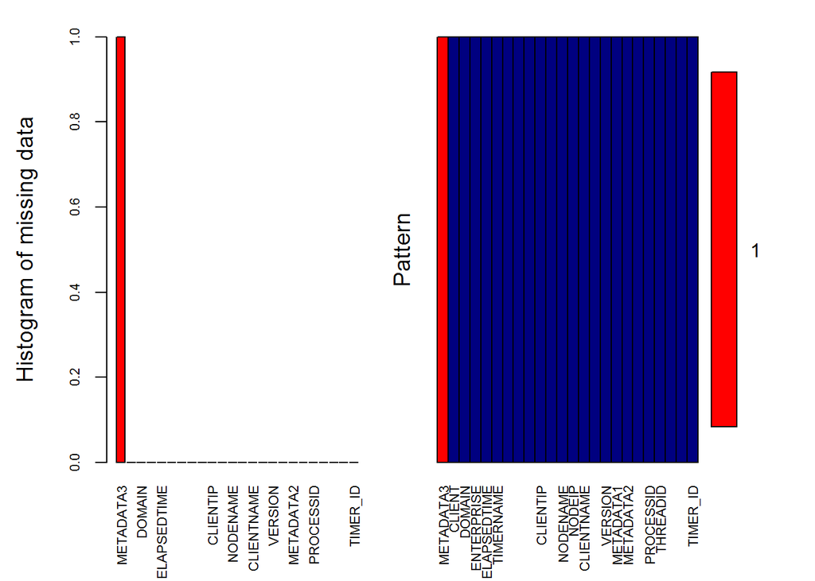

```
##
##  Variables sorted by number of missings:
##          Variable Count
##         METADATA3     1
##            CLIENT     0
##            DOMAIN     0
##        ENTERPRISE     0
##       ELAPSEDTIME     0
##         TIMERNAME     0
##    PROPERTYVALUES     0
##  FRAMEWORKVERSION     0
##       ENDDATETIME     0
##          CLIENTIP     0
##    USERPRINCIPALS     0
##          NODENAME     0
##            NODEIP     0
##        CLIENTNAME     0
##   APPLICATIONNAME     0
##           VERSION     0
##         METADATA1     0
##         METADATA2     0
##       RESULTCOUNT     0
##         PROCESSID     0
##          THREADID     0
##      START_OFFSET     0
##       STOP_OFFSET     0
##          TIMER_ID     0
```

```r
aggr_plot <- aggr(timer, col=c('navyblue','red'), numbers=TRUE, sortVars=TRUE, labels=names(timer), cex.axis=.7, gap=3, ylab=c("Histogram of missing data","Pattern"))
```

```r
timer$METADATA3 = NULL
timer <- timer[which(timer$ELAPSEDTIME>=0 & timer$ELAPSEDTIME<=200),]
```

Timer frequencies tells us which timers are most used by users.

```r
freqData <- as.data.frame(table(timer$TIMERNAME))
freqData <- freqData[order(-freqData$Freq), ]
kable(freqData)
```

|  | Var1 | Freq |
| --- | --- | --- |
| 71 | USR:MPG.RCM.UTILIZATION_MANAGEMENT - LOAD COMPONENT | 454991 |
| 4 | CAP:RCM-LAUNCH-MPAGE-5.X | 251679 |
| 55 | USR:MPG.RCM.DISCHARGEREVIEWWORKLIST - GET ORDER DETAILS | 52845 |
| 10 | CAP:RCM_UM_WORKLIST.01 | 48069 |
| 8 | CAP:RCM_DISCHARGE_WORKLIST.01 | 46659 |
| 72 | USR:MPG.RCM.UTILIZATIONREVIEWWORKLIST - GET ORDER DETAILS | 39548 |
| 48 | USR:MPG.RCM.CLINICAL_REVIEW - MODIFY MANUAL CLINICAL REVIEW | 28109 |
| 1 | CAP:MPG.RCM.POST-ACUTE-CURASPAN | 25138 |
| 43 | USR:MPG.RCM.CLINICAL_REVIEW - ADD INTERQUAL CLINICAL REVIEW | 18216 |
| 49 | USR:MPG.RCM.CLINICAL_REVIEW - SEND CLINICAL FAX | 8329 |
| 44 | USR:MPG.RCM.CLINICAL_REVIEW - ADD MANUAL CLINICAL REVIEW | 5564 |
| 3 | CAP:RCM-LAUNCH-ENSOCARE-SHA2 | 5553 |
| 46 | USR:MPG.RCM.CLINICAL_REVIEW - LOAD INTERQUAL CLINICAL REVIEW | 3426 |
| 42 | USR:MPG.RCM.CLINICAL_REVIEW - ADD CLINICAL REVIEW ADDENDUMS | 3129 |
| 70 | USR:MPG.RCM.SEARCH | 1687 |
| 57 | USR:MPG.RCM.DISCHARGEREVIEWWORKLIST - GET WORKLIST ITEM DETAILS | 1005 |
| 7 | CAP:RCM_DENIED_DAYS_WORKLIST.01 | 820 |
| 74 | USR:MPG.RCM.UTILIZATIONREVIEWWORKLIST - GET WORKLIST ITEM DETAILS | 781 |
| 9 | CAP:RCM_NAVI_SEND_CCD_01 | 619 |
| 64 | USR:MPG.RCM.POST_ACUTE_PLACEMENT - SEND XR PACKET | 307 |
| 13 | ENG:MPG.RCM.CLINICAL_REVIEW | 216 |
| 5 | CAP:RCM_APPEALS_WORKLIST.01 | 214 |
| 12 | ENG:MPG.RCM.CARE_MGMT | 187 |
| 67 | USR:MPG.RCM.POST_ACUTE_SERVICES - SEND XR PACKET | 143 |
| 26 | ENG:MPG.RCM.DOC_REVIEW | 132 |
| 40 | USR:MPG.RCM.CARE_MGMT - LOAD COMPONENT | 132 |
| 59 | USR:MPG.RCM.INS_INFO - LOAD COMPONENT | 130 |
| 24 | ENG:MPG.RCM.DENIED_DAYS | 129 |
| 45 | USR:MPG.RCM.CLINICAL_REVIEW - LOAD COMPONENT | 121 |
| 11 | ENG:MPG.RCM.AVOID_DAYS | 112 |
| 31 | ENG:MPG.RCM.POST_ACUTE_SERVICES | 109 |
| 53 | USR:MPG.RCM.DENIED_DAYS - LOAD COMPONENT | 102 |
| 58 | USR:MPG.RCM.DOC_REVIEW - LOAD COMPONENT | 102 |
| 38 | USR:MPG.RCM.AVOID_DAYS - LOAD COMPONENT | 93 |
| 30 | ENG:MPG.RCM.POST_ACUTE_PLACEMENT | 88 |
| 22 | ENG:MPG.RCM.CURASPAN | 82 |
| 66 | USR:MPG.RCM.POST_ACUTE_SERVICES - LOAD COMPONENT | 82 |
| 27 | ENG:MPG.RCM.INS_INFO | 74 |
| 29 | ENG:MPG.RCM.PACKET_FORM | 74 |
| 63 | USR:MPG.RCM.POST_ACUTE_PLACEMENT - LOAD COMPONENT | 72 |
| 75 | USR:MPG.RCM.VISIT_INFO - LOAD COMPONENT | 71 |
| 41 | USR:MPG.RCM.CLINICAL_REVIEW | 69 |
| 19 | ENG:MPG.RCM.COMMON | 65 |
| 51 | USR:MPG.RCM.CURASPAN - LOAD COMPONENT | 64 |
| 60 | USR:MPG.RCM.NOTES_LIST - LOAD COMPONENT | 64 |
| 32 | ENG:MPG.RCM.READMISSION | 53 |
| 69 | USR:MPG.RCM.READMISSION - LOAD COMPONENT | 53 |
| 28 | ENG:MPG.RCM.NOTES_LIST | 48 |
| 34 | ENG:MPG.RCM.VISIT_INFO | 46 |
| 2 | CAP:MPG.RCM.RECOMMENDED DISPOSITION | 45 |
| 56 | USR:MPG.RCM.DISCHARGEREVIEWWORKLIST - GET READMISSION RISK DETAILS | 44 |
| 36 | ENG:RCM.DOCUMENTREVIEWWORKLIST | 41 |
| 54 | USR:MPG.RCM.DISCHARGE_PLANNING - LOAD COMPONENT | 33 |
| 33 | ENG:MPG.RCM.SEARCH | 32 |
| 61 | USR:MPG.RCM.PACKET_FORM | 32 |
| 39 | USR:MPG.RCM.CARE_MGMT | 28 |
| 23 | ENG:MPG.RCM.CURASPAN - GET UPLOADS | 25 |
| 25 | ENG:MPG.RCM.DISCHARGE_PLANNING | 25 |
| 65 | USR:MPG.RCM.POST_ACUTE_SERVICES | 25 |
| 37 | ENG:RCM.UMASSIGNMENTWORKLIST | 23 |
| 52 | USR:MPG.RCM.DENIED_DAYS | 19 |
| 73 | USR:MPG.RCM.UTILIZATIONREVIEWWORKLIST - GET READMISSION RISK DETAILS | 13 |
| 68 | USR:MPG.RCM.READMISSION | 11 |
| 21 | ENG:MPG.RCM.COMMON - MAKE WEB SERVICE CALL | 8 |
| 6 | CAP:RCM_CDI_FINAL_DRG_01 | 6 |
| 15 | ENG:MPG.RCM.CLINICAL_REVIEW - GET PAYER COMMUNICATION INFO | 6 |
| 62 | USR:MPG.RCM.POST_ACUTE_PLACEMENT | 5 |
| 17 | ENG:MPG.RCM.CLINICAL_REVIEW - OPEN SECONDARY REVIEW DIALOG | 4 |
| 20 | ENG:MPG.RCM.COMMON - CREATE OAUTH SESSION | 4 |
| 50 | USR:MPG.RCM.CURASPAN | 4 |
| 16 | ENG:MPG.RCM.CLINICAL_REVIEW - MODIFY MANUAL CLINICAL REVIEW | 3 |
| 35 | ENG:RCM.ASSIGNMENTWORKLIST | 2 |
| 47 | USR:MPG.RCM.CLINICAL_REVIEW - MODIFY INTERQUAL CLINICAL REVIEW | 2 |
| 14 | ENG:MPG.RCM.CLINICAL_REVIEW - ADD MANUAL CLINICAL REVIEW | 1 |
| 18 | ENG:MPG.RCM.CLINICAL_REVIEW - SAVE TO CAMM | 1 |

The Median elapsed time shows what is the median time of each timers. They are also ordered by response time.

```r
timerMedian <- aggregate(data = timer, ELAPSEDTIME ~ TIMERNAME, median, na.rm = TRUE)
timerMedian <- timerMedian[order(-timerMedian$ELAPSEDTIME), ]
kable(timerMedian)
```

|  | TIMERNAME | ELAPSEDTIME |
| --- | --- | --- |
| 64 | USR:MPG.RCM.POST_ACUTE_PLACEMENT - SEND XR PACKET | 36.9147458 |
| 67 | USR:MPG.RCM.POST_ACUTE_SERVICES - SEND XR PACKET | 24.3283462 |
| 18 | ENG:MPG.RCM.CLINICAL_REVIEW - SAVE TO CAMM | 15.5404643 |
| 20 | ENG:MPG.RCM.COMMON - CREATE OAUTH SESSION | 9.1736951 |
| 21 | ENG:MPG.RCM.COMMON - MAKE WEB SERVICE CALL | 5.3060841 |
| 36 | ENG:RCM.DOCUMENTREVIEWWORKLIST | 3.4158445 |
| 14 | ENG:MPG.RCM.CLINICAL_REVIEW - ADD MANUAL CLINICAL REVIEW | 2.8141735 |
| 61 | USR:MPG.RCM.PACKET_FORM | 2.3510557 |
| 65 | USR:MPG.RCM.POST_ACUTE_SERVICES | 2.1998459 |
| 47 | USR:MPG.RCM.CLINICAL_REVIEW - MODIFY INTERQUAL CLINICAL REVIEW | 1.8011021 |
| 29 | ENG:MPG.RCM.PACKET_FORM | 1.7974363 |
| 35 | ENG:RCM.ASSIGNMENTWORKLIST | 1.6184861 |
| 6 | CAP:RCM_CDI_FINAL_DRG_01 | 1.0518445 |
| 43 | USR:MPG.RCM.CLINICAL_REVIEW - ADD INTERQUAL CLINICAL REVIEW | 1.0404357 |
| 51 | USR:MPG.RCM.CURASPAN - LOAD COMPONENT | 0.9499922 |
| 69 | USR:MPG.RCM.READMISSION - LOAD COMPONENT | 0.9266129 |
| 50 | USR:MPG.RCM.CURASPAN | 0.8742446 |
| 45 | USR:MPG.RCM.CLINICAL_REVIEW - LOAD COMPONENT | 0.8377129 |
| 62 | USR:MPG.RCM.POST_ACUTE_PLACEMENT | 0.8213953 |
| 17 | ENG:MPG.RCM.CLINICAL_REVIEW - OPEN SECONDARY REVIEW DIALOG | 0.7716867 |
| 15 | ENG:MPG.RCM.CLINICAL_REVIEW - GET PAYER COMMUNICATION INFO | 0.7566619 |
| 52 | USR:MPG.RCM.DENIED_DAYS | 0.7053825 |
| 75 | USR:MPG.RCM.VISIT_INFO - LOAD COMPONENT | 0.6938299 |
| 37 | ENG:RCM.UMASSIGNMENTWORKLIST | 0.6545477 |
| 63 | USR:MPG.RCM.POST_ACUTE_PLACEMENT - LOAD COMPONENT | 0.6388793 |
| 73 | USR:MPG.RCM.UTILIZATIONREVIEWWORKLIST - GET READMISSION RISK DETAILS | 0.6345735 |
| 38 | USR:MPG.RCM.AVOID_DAYS - LOAD COMPONENT | 0.6272750 |
| 39 | USR:MPG.RCM.CARE_MGMT | 0.6261176 |
| 66 | USR:MPG.RCM.POST_ACUTE_SERVICES - LOAD COMPONENT | 0.6150016 |
| 56 | USR:MPG.RCM.DISCHARGEREVIEWWORKLIST - GET READMISSION RISK DETAILS | 0.5979107 |
| 58 | USR:MPG.RCM.DOC_REVIEW - LOAD COMPONENT | 0.5808528 |
| 23 | ENG:MPG.RCM.CURASPAN - GET UPLOADS | 0.5323674 |
| 49 | USR:MPG.RCM.CLINICAL_REVIEW - SEND CLINICAL FAX | 0.5231792 |
| 60 | USR:MPG.RCM.NOTES_LIST - LOAD COMPONENT | 0.5164271 |
| 40 | USR:MPG.RCM.CARE_MGMT - LOAD COMPONENT | 0.5060691 |
| 59 | USR:MPG.RCM.INS_INFO - LOAD COMPONENT | 0.4864422 |
| 53 | USR:MPG.RCM.DENIED_DAYS - LOAD COMPONENT | 0.4847276 |
| 16 | ENG:MPG.RCM.CLINICAL_REVIEW - MODIFY MANUAL CLINICAL REVIEW | 0.4777960 |
| 19 | ENG:MPG.RCM.COMMON | 0.4525146 |
| 54 | USR:MPG.RCM.DISCHARGE_PLANNING - LOAD COMPONENT | 0.4093508 |
| 41 | USR:MPG.RCM.CLINICAL_REVIEW | 0.3850158 |
| 42 | USR:MPG.RCM.CLINICAL_REVIEW - ADD CLINICAL REVIEW ADDENDUMS | 0.2925467 |
| 48 | USR:MPG.RCM.CLINICAL_REVIEW - MODIFY MANUAL CLINICAL REVIEW | 0.2902371 |
| 74 | USR:MPG.RCM.UTILIZATIONREVIEWWORKLIST - GET WORKLIST ITEM DETAILS | 0.2510377 |
| 57 | USR:MPG.RCM.DISCHARGEREVIEWWORKLIST - GET WORKLIST ITEM DETAILS | 0.2457538 |
| 44 | USR:MPG.RCM.CLINICAL_REVIEW - ADD MANUAL CLINICAL REVIEW | 0.2213731 |
| 33 | ENG:MPG.RCM.SEARCH | 0.2187638 |
| 70 | USR:MPG.RCM.SEARCH | 0.1802800 |
| 71 | USR:MPG.RCM.UTILIZATION_MANAGEMENT - LOAD COMPONENT | 0.1399051 |
| 46 | USR:MPG.RCM.CLINICAL_REVIEW - LOAD INTERQUAL CLINICAL REVIEW | 0.1021825 |
| 13 | ENG:MPG.RCM.CLINICAL_REVIEW | 0.0903702 |
| 68 | USR:MPG.RCM.READMISSION | 0.0615772 |
| 55 | USR:MPG.RCM.DISCHARGEREVIEWWORKLIST - GET ORDER DETAILS | 0.0615435 |
| 72 | USR:MPG.RCM.UTILIZATIONREVIEWWORKLIST - GET ORDER DETAILS | 0.0564152 |
| 34 | ENG:MPG.RCM.VISIT_INFO | 0.0432522 |
| 12 | ENG:MPG.RCM.CARE_MGMT | 0.0345561 |
| 28 | ENG:MPG.RCM.NOTES_LIST | 0.0216667 |
| 32 | ENG:MPG.RCM.READMISSION | 0.0203008 |
| 27 | ENG:MPG.RCM.INS_INFO | 0.0180075 |
| 30 | ENG:MPG.RCM.POST_ACUTE_PLACEMENT | 0.0156494 |
| 24 | ENG:MPG.RCM.DENIED_DAYS | 0.0152705 |
| 11 | ENG:MPG.RCM.AVOID_DAYS | 0.0147609 |
| 31 | ENG:MPG.RCM.POST_ACUTE_SERVICES | 0.0136306 |
| 26 | ENG:MPG.RCM.DOC_REVIEW | 0.0092034 |
| 22 | ENG:MPG.RCM.CURASPAN | 0.0084534 |
| 25 | ENG:MPG.RCM.DISCHARGE_PLANNING | 0.0056108 |
| 2 | CAP:MPG.RCM.RECOMMENDED DISPOSITION | 0.0008423 |
| 10 | CAP:RCM_UM_WORKLIST.01 | 0.0004344 |
| 4 | CAP:RCM-LAUNCH-MPAGE-5.X | 0.0002029 |
| 1 | CAP:MPG.RCM.POST-ACUTE-CURASPAN | 0.0002028 |
| 3 | CAP:RCM-LAUNCH-ENSOCARE-SHA2 | 0.0002009 |
| 9 | CAP:RCM_NAVI_SEND_CCD_01 | 0.0000603 |
| 5 | CAP:RCM_APPEALS_WORKLIST.01 | 0.0000000 |
| 7 | CAP:RCM_DENIED_DAYS_WORKLIST.01 | 0.0000000 |
| 8 | CAP:RCM_DISCHARGE_WORKLIST.01 | 0.0000000 |

The mean elapsed time of each timers. The plot shows two send packet timers are the slownest by far.

```r
timerAvg <- aggregate(data = timer, ELAPSEDTIME ~ TIMERNAME, mean, na.rm = TRUE)
dim(timerAvg)
```

```
## [1] 75  2
```

```r
str(timerAvg)
```

```
## 'data.frame':    75 obs. of  2 variables:
##  $ TIMERNAME  : Factor w/ 75 levels "CAP:MPG.RCM.POST-ACUTE-CURASPAN",..: 1 2 3 4 5 6 7 8 9 10 ...
##  $ ELAPSEDTIME: num  0.0002295 0.0008 0.0002275 0.0002237 0.0000654 ...
```

```r
timerAvg <- timerAvg[order(-timerAvg$ELAPSEDTIME), ]
kable(timerAvg)
```

|  | TIMERNAME | ELAPSEDTIME |
| --- | --- | --- |
| 64 | USR:MPG.RCM.POST_ACUTE_PLACEMENT - SEND XR PACKET | 50.6544494 |
| 67 | USR:MPG.RCM.POST_ACUTE_SERVICES - SEND XR PACKET | 41.2476987 |
| 18 | ENG:MPG.RCM.CLINICAL_REVIEW - SAVE TO CAMM | 15.5404643 |
| 21 | ENG:MPG.RCM.COMMON - MAKE WEB SERVICE CALL | 12.9006355 |
| 36 | ENG:RCM.DOCUMENTREVIEWWORKLIST | 11.4115214 |
| 20 | ENG:MPG.RCM.COMMON - CREATE OAUTH SESSION | 9.1685405 |
| 65 | USR:MPG.RCM.POST_ACUTE_SERVICES | 6.3874888 |
| 63 | USR:MPG.RCM.POST_ACUTE_PLACEMENT - LOAD COMPONENT | 4.3847261 |
| 51 | USR:MPG.RCM.CURASPAN - LOAD COMPONENT | 4.0980003 |
| 19 | ENG:MPG.RCM.COMMON | 3.8681922 |
| 29 | ENG:MPG.RCM.PACKET_FORM | 3.8151138 |
| 61 | USR:MPG.RCM.PACKET_FORM | 3.6206926 |
| 62 | USR:MPG.RCM.POST_ACUTE_PLACEMENT | 3.3584328 |
| 14 | ENG:MPG.RCM.CLINICAL_REVIEW - ADD MANUAL CLINICAL REVIEW | 2.8141735 |
| 43 | USR:MPG.RCM.CLINICAL_REVIEW - ADD INTERQUAL CLINICAL REVIEW | 2.7850492 |
| 16 | ENG:MPG.RCM.CLINICAL_REVIEW - MODIFY MANUAL CLINICAL REVIEW | 2.5649641 |
| 50 | USR:MPG.RCM.CURASPAN | 2.3848604 |
| 75 | USR:MPG.RCM.VISIT_INFO - LOAD COMPONENT | 2.3372491 |
| 41 | USR:MPG.RCM.CLINICAL_REVIEW | 2.2908528 |
| 58 | USR:MPG.RCM.DOC_REVIEW - LOAD COMPONENT | 2.0532926 |
| 45 | USR:MPG.RCM.CLINICAL_REVIEW - LOAD COMPONENT | 2.0103760 |
| 60 | USR:MPG.RCM.NOTES_LIST - LOAD COMPONENT | 1.8510705 |
| 39 | USR:MPG.RCM.CARE_MGMT | 1.8175807 |
| 38 | USR:MPG.RCM.AVOID_DAYS - LOAD COMPONENT | 1.8037716 |
| 47 | USR:MPG.RCM.CLINICAL_REVIEW - MODIFY INTERQUAL CLINICAL REVIEW | 1.8011021 |
| 69 | USR:MPG.RCM.READMISSION - LOAD COMPONENT | 1.7041224 |
| 40 | USR:MPG.RCM.CARE_MGMT - LOAD COMPONENT | 1.6951551 |
| 54 | USR:MPG.RCM.DISCHARGE_PLANNING - LOAD COMPONENT | 1.6866780 |
| 17 | ENG:MPG.RCM.CLINICAL_REVIEW - OPEN SECONDARY REVIEW DIALOG | 1.6199929 |
| 35 | ENG:RCM.ASSIGNMENTWORKLIST | 1.6184861 |
| 66 | USR:MPG.RCM.POST_ACUTE_SERVICES - LOAD COMPONENT | 1.4965280 |
| 37 | ENG:RCM.UMASSIGNMENTWORKLIST | 1.2363155 |
| 59 | USR:MPG.RCM.INS_INFO - LOAD COMPONENT | 1.1750107 |
| 6 | CAP:RCM_CDI_FINAL_DRG_01 | 1.0660867 |
| 52 | USR:MPG.RCM.DENIED_DAYS | 1.0234161 |
| 23 | ENG:MPG.RCM.CURASPAN - GET UPLOADS | 0.8853208 |
| 15 | ENG:MPG.RCM.CLINICAL_REVIEW - GET PAYER COMMUNICATION INFO | 0.8515326 |
| 56 | USR:MPG.RCM.DISCHARGEREVIEWWORKLIST - GET READMISSION RISK DETAILS | 0.8368531 |
| 53 | USR:MPG.RCM.DENIED_DAYS - LOAD COMPONENT | 0.7414158 |
| 49 | USR:MPG.RCM.CLINICAL_REVIEW - SEND CLINICAL FAX | 0.7083893 |
| 73 | USR:MPG.RCM.UTILIZATIONREVIEWWORKLIST - GET READMISSION RISK DETAILS | 0.6428600 |
| 57 | USR:MPG.RCM.DISCHARGEREVIEWWORKLIST - GET WORKLIST ITEM DETAILS | 0.5246419 |
| 33 | ENG:MPG.RCM.SEARCH | 0.5162222 |
| 13 | ENG:MPG.RCM.CLINICAL_REVIEW | 0.3748412 |
| 74 | USR:MPG.RCM.UTILIZATIONREVIEWWORKLIST - GET WORKLIST ITEM DETAILS | 0.3487838 |
| 42 | USR:MPG.RCM.CLINICAL_REVIEW - ADD CLINICAL REVIEW ADDENDUMS | 0.3361013 |
| 48 | USR:MPG.RCM.CLINICAL_REVIEW - MODIFY MANUAL CLINICAL REVIEW | 0.3308166 |
| 31 | ENG:MPG.RCM.POST_ACUTE_SERVICES | 0.3226916 |
| 46 | USR:MPG.RCM.CLINICAL_REVIEW - LOAD INTERQUAL CLINICAL REVIEW | 0.2587542 |
| 44 | USR:MPG.RCM.CLINICAL_REVIEW - ADD MANUAL CLINICAL REVIEW | 0.2531629 |
| 71 | USR:MPG.RCM.UTILIZATION_MANAGEMENT - LOAD COMPONENT | 0.2041105 |
| 70 | USR:MPG.RCM.SEARCH | 0.1870997 |
| 11 | ENG:MPG.RCM.AVOID_DAYS | 0.1761337 |
| 24 | ENG:MPG.RCM.DENIED_DAYS | 0.1606298 |
| 12 | ENG:MPG.RCM.CARE_MGMT | 0.1191851 |
| 30 | ENG:MPG.RCM.POST_ACUTE_PLACEMENT | 0.1113914 |
| 55 | USR:MPG.RCM.DISCHARGEREVIEWWORKLIST - GET ORDER DETAILS | 0.0953762 |
| 72 | USR:MPG.RCM.UTILIZATIONREVIEWWORKLIST - GET ORDER DETAILS | 0.0784165 |
| 68 | USR:MPG.RCM.READMISSION | 0.0578875 |
| 34 | ENG:MPG.RCM.VISIT_INFO | 0.0530670 |
| 32 | ENG:MPG.RCM.READMISSION | 0.0406420 |
| 22 | ENG:MPG.RCM.CURASPAN | 0.0367261 |
| 28 | ENG:MPG.RCM.NOTES_LIST | 0.0318742 |
| 27 | ENG:MPG.RCM.INS_INFO | 0.0204576 |
| 26 | ENG:MPG.RCM.DOC_REVIEW | 0.0141285 |
| 25 | ENG:MPG.RCM.DISCHARGE_PLANNING | 0.0079212 |
| 9 | CAP:RCM_NAVI_SEND_CCD_01 | 0.0012548 |
| 2 | CAP:MPG.RCM.RECOMMENDED DISPOSITION | 0.0008000 |
| 10 | CAP:RCM_UM_WORKLIST.01 | 0.0004424 |
| 1 | CAP:MPG.RCM.POST-ACUTE-CURASPAN | 0.0002295 |
| 3 | CAP:RCM-LAUNCH-ENSOCARE-SHA2 | 0.0002275 |
| 4 | CAP:RCM-LAUNCH-MPAGE-5.X | 0.0002237 |
| 7 | CAP:RCM_DENIED_DAYS_WORKLIST.01 | 0.0002103 |
| 5 | CAP:RCM_APPEALS_WORKLIST.01 | 0.0000654 |
| 8 | CAP:RCM_DISCHARGE_WORKLIST.01 | 0.0000483 |

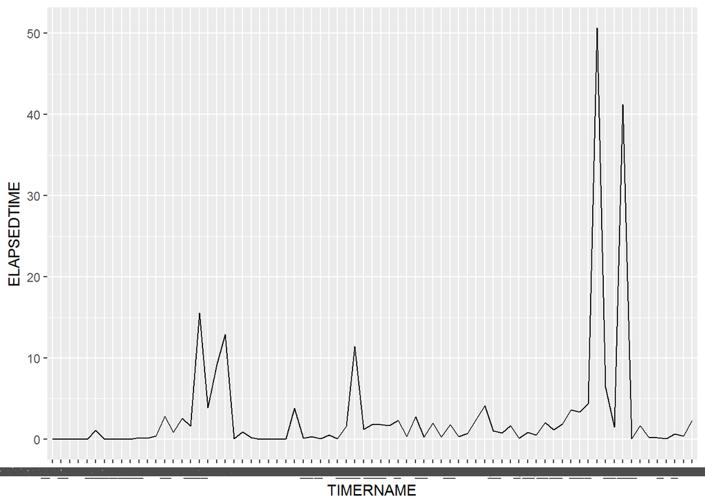

```r
rownames(timerAvg)<-timerAvg$TIMERNAME
ggplot(data=timerAvg, aes(x=TIMERNAME, y=ELAPSEDTIME, group=1)) + geom_line()
```

```r
timerAvg$TIMERNAME <- NULL
```

If we group by users mean elapsed time then we know what each users are experiencing overall.

```r
userTimerAvg <- aggregate(data = timer, ELAPSEDTIME ~ USERPRINCIPALS, mean, na.rm = TRUE)
dim(userTimerAvg)
```

```
## [1] 11375     2
```

```r
str(userTimerAvg)
```

```
## 'data.frame':    11375 obs. of  2 variables:
##  $ USERPRINCIPALS: Factor w/ 11375 levels "001161","001338",..: 1 2 3 4 5 6 7 8 9 10 ...
##  $ ELAPSEDTIME   : num  0.1087 0.1427 0.0595 0.0515 0.1076 ...
```

```r
#userTimerAvg
```

### 1. Hierarchical clustering on Timer average time

```r
dissimilarity.matrix <- dist(as.matrix(timerAvg, method="euclidean"))
timer_hclust <- hclust(dissimilarity.matrix, method="ward.D")

dendrogram_table <- as.data.frame(timer_hclust$height)
print(dendrogram_table)
```

```
##    timer_hclust$height
## 1       0.000002028786
## 2       0.000005718788
## 3       0.000017134057
## 4       0.000022851127
## 5       0.000345393955
## 6       0.000454838653
## 7       0.000479828878
## 8       0.001506820250
## 9       0.002005370309
## 10      0.002669543468
## 11      0.003915910090
## 12      0.004820455848
## 13      0.005284696829
## 14      0.005591317903
```

[output cut: 60 more lines]

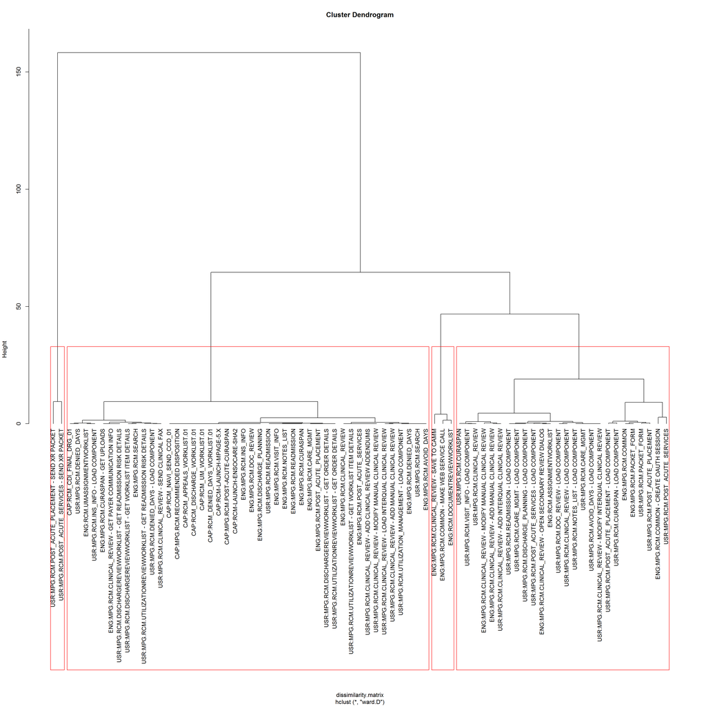

```r
plot(timer_hclust, hang = -1)
rect.hclust(timer_hclust, k=4, border="red")
```

### 2. Association rule by Apriori on User sessions

Another interesting to do is to look at each users’ timer data and run an association rule algorithm on them to see strong rules. I think a typical rule would be one user action 1 leads to user action 2.

```r
timer_user <- subset(timer, select = c('USERPRINCIPALS', 'TIMERNAME'))
timerNames <- unique(timer_user$TIMERNAME)
length(timerNames)
```

```
## [1] 75
```

```r
users <- unique(timer_user$USERPRINCIPALS)
length(users)
```

```
## [1] 11375
```

```r
# only going to look at timer and user columns
timer_user <- timer_user[order(timer_user$USERPRINCIPALS),]
dim(timer_user)
```

```
## [1] 999843      2
```

```r
head(timer_user)
```

```
##        USERPRINCIPALS
## 684056         001161
## 684115         001161
## 684160         001161
## 684161         001161
## 684847         001161
## 686822         001161
##                                                        TIMERNAME
## 684056                                    CAP:RCM_UM_WORKLIST.01
## 684115 USR:MPG.RCM.UTILIZATIONREVIEWWORKLIST - GET ORDER DETAILS
## 684160                                  CAP:RCM-LAUNCH-MPAGE-5.X
## 684161       USR:MPG.RCM.UTILIZATION_MANAGEMENT - LOAD COMPONENT
## 684847           USR:MPG.RCM.CLINICAL_REVIEW - SEND CLINICAL FAX
## 686822                                  CAP:RCM-LAUNCH-MPAGE-5.X
```

Convert dataframe to a transaction.

```r
userTransaction <- matrix(0, nrow = 11375, ncol = 1)
for (i in 1:length(users)) {
    timerForUser <- filter(timer_user, timer_user$USERPRINCIPALS==users[i])
    ### flatten unique timer name into a single line
    uniqueTimerForUser <- unique(timerForUser$TIMERNAME);
    singleline <- paste(uniqueTimerForUser, collapse = ',')
    userTransaction[i,] <- singleline
}

## write the transaction
#trans <- as(timer_user, "transactions") does not combine user transactions
write(userTransaction, file="C:/Users/lj015625/Desktop/DataMining Class/Final/Data/timer_basket")
userTran<-read.transactions("C:/Users/lj015625/Desktop/DataMining Class/Final/Data/timer_basket", format="basket", sep=",")
```

```r
dim(userTran)
```

```
## [1] 11375    75
```

```r
freq_userTran_df <- as.data.frame(itemFrequency(userTran))
kable(freq_userTran_df)
```

|  | itemFrequency(userTran) |
| --- | --- |
| CAP:MPG.RCM.POST-ACUTE-CURASPAN | 0.1064615 |
| CAP:MPG.RCM.RECOMMENDED DISPOSITION | 0.0007912 |
| CAP:RCM-LAUNCH-ENSOCARE-SHA2 | 0.0685714 |
| CAP:RCM-LAUNCH-MPAGE-5.X | 0.5410110 |
| CAP:RCM_APPEALS_WORKLIST.01 | 0.0091429 |
| CAP:RCM_CDI_FINAL_DRG_01 | 0.0001758 |
| CAP:RCM_DENIED_DAYS_WORKLIST.01 | 0.0140659 |
| CAP:RCM_DISCHARGE_WORKLIST.01 | 0.3360879 |
| CAP:RCM_NAVI_SEND_CCD_01 | 0.0000879 |
| CAP:RCM_UM_WORKLIST.01 | 0.2676044 |
| ENG:MPG.RCM.AVOID_DAYS | 0.0009670 |
| ENG:MPG.RCM.CARE_MGMT | 0.0009670 |
| ENG:MPG.RCM.CLINICAL_REVIEW | 0.0010549 |
| ENG:MPG.RCM.CLINICAL_REVIEW - ADD MANUAL CLINICAL REVIEW | 0.0000879 |
| ENG:MPG.RCM.CLINICAL_REVIEW - GET PAYER COMMUNICATION INFO | 0.0001758 |
| ENG:MPG.RCM.CLINICAL_REVIEW - MODIFY MANUAL CLINICAL REVIEW | 0.0001758 |
| ENG:MPG.RCM.CLINICAL_REVIEW - OPEN SECONDARY REVIEW DIALOG | 0.0000879 |
| ENG:MPG.RCM.CLINICAL_REVIEW - SAVE TO CAMM | 0.0000879 |
| ENG:MPG.RCM.COMMON | 0.0008791 |
| ENG:MPG.RCM.COMMON - CREATE OAUTH SESSION | 0.0000879 |
| ENG:MPG.RCM.COMMON - MAKE WEB SERVICE CALL | 0.0000879 |
| ENG:MPG.RCM.CURASPAN | 0.0009670 |
| ENG:MPG.RCM.CURASPAN - GET UPLOADS | 0.0002637 |
| ENG:MPG.RCM.DENIED_DAYS | 0.0008791 |
| ENG:MPG.RCM.DISCHARGE_PLANNING | 0.0009670 |
| ENG:MPG.RCM.DOC_REVIEW | 0.0010549 |
| ENG:MPG.RCM.INS_INFO | 0.0009670 |
| ENG:MPG.RCM.NOTES_LIST | 0.0012308 |
| ENG:MPG.RCM.PACKET_FORM | 0.0002637 |
| ENG:MPG.RCM.POST_ACUTE_PLACEMENT | 0.0009670 |
| ENG:MPG.RCM.POST_ACUTE_SERVICES | 0.0009670 |
| ENG:MPG.RCM.READMISSION | 0.0008791 |
| ENG:MPG.RCM.SEARCH | 0.0003516 |
| ENG:MPG.RCM.VISIT_INFO | 0.0009670 |
| ENG:RCM.ASSIGNMENTWORKLIST | 0.0000879 |
| ENG:RCM.DOCUMENTREVIEWWORKLIST | 0.0006154 |
| ENG:RCM.UMASSIGNMENTWORKLIST | 0.0001758 |
| USR:MPG.RCM.AVOID_DAYS - LOAD COMPONENT | 0.0014066 |
| USR:MPG.RCM.CARE_MGMT | 0.0001758 |
| USR:MPG.RCM.CARE_MGMT - LOAD COMPONENT | 0.0021099 |
| USR:MPG.RCM.CLINICAL_REVIEW | 0.0005275 |
| USR:MPG.RCM.CLINICAL_REVIEW - ADD CLINICAL REVIEW ADDENDUMS | 0.0455385 |
| USR:MPG.RCM.CLINICAL_REVIEW - ADD INTERQUAL CLINICAL REVIEW | 0.0981099 |
| USR:MPG.RCM.CLINICAL_REVIEW - ADD MANUAL CLINICAL REVIEW | 0.0339341 |
| USR:MPG.RCM.CLINICAL_REVIEW - LOAD COMPONENT | 0.0014066 |
| USR:MPG.RCM.CLINICAL_REVIEW - LOAD INTERQUAL CLINICAL REVIEW | 0.0346374 |
| USR:MPG.RCM.CLINICAL_REVIEW - MODIFY INTERQUAL CLINICAL REVIEW | 0.0001758 |
| USR:MPG.RCM.CLINICAL_REVIEW - MODIFY MANUAL CLINICAL REVIEW | 0.1211429 |
| USR:MPG.RCM.CLINICAL_REVIEW - SEND CLINICAL FAX | 0.0720879 |
| USR:MPG.RCM.CURASPAN | 0.0000879 |
| USR:MPG.RCM.CURASPAN - LOAD COMPONENT | 0.0009670 |
| USR:MPG.RCM.DENIED_DAYS | 0.0001758 |
| USR:MPG.RCM.DENIED_DAYS - LOAD COMPONENT | 0.0012308 |
| USR:MPG.RCM.DISCHARGE_PLANNING - LOAD COMPONENT | 0.0014066 |
| USR:MPG.RCM.DISCHARGEREVIEWWORKLIST - GET ORDER DETAILS | 0.2168791 |
| USR:MPG.RCM.DISCHARGEREVIEWWORKLIST - GET READMISSION RISK DETAILS | 0.0020220 |
| USR:MPG.RCM.DISCHARGEREVIEWWORKLIST - GET WORKLIST ITEM DETAILS | 0.0408791 |
| USR:MPG.RCM.DOC_REVIEW - LOAD COMPONENT | 0.0014066 |
| USR:MPG.RCM.INS_INFO - LOAD COMPONENT | 0.0020220 |
| USR:MPG.RCM.NOTES_LIST - LOAD COMPONENT | 0.0020220 |
| USR:MPG.RCM.PACKET_FORM | 0.0002637 |
| USR:MPG.RCM.POST_ACUTE_PLACEMENT | 0.0001758 |
| USR:MPG.RCM.POST_ACUTE_PLACEMENT - LOAD COMPONENT | 0.0014945 |
| USR:MPG.RCM.POST_ACUTE_PLACEMENT - SEND XR PACKET | 0.0112527 |
| USR:MPG.RCM.POST_ACUTE_SERVICES | 0.0001758 |
| USR:MPG.RCM.POST_ACUTE_SERVICES - LOAD COMPONENT | 0.0014945 |
| USR:MPG.RCM.POST_ACUTE_SERVICES - SEND XR PACKET | 0.0034286 |
| USR:MPG.RCM.READMISSION | 0.0001758 |
| USR:MPG.RCM.READMISSION - LOAD COMPONENT | 0.0012308 |
| USR:MPG.RCM.SEARCH | 0.0115165 |
| USR:MPG.RCM.UTILIZATION_MANAGEMENT - LOAD COMPONENT | 0.7949890 |
| USR:MPG.RCM.UTILIZATIONREVIEWWORKLIST - GET ORDER DETAILS | 0.1501538 |
| USR:MPG.RCM.UTILIZATIONREVIEWWORKLIST - GET READMISSION RISK DETAILS | 0.0010549 |
| USR:MPG.RCM.UTILIZATIONREVIEWWORKLIST - GET WORKLIST ITEM DETAILS | 0.0271648 |
| USR:MPG.RCM.VISIT_INFO - LOAD COMPONENT | 0.0019341 |

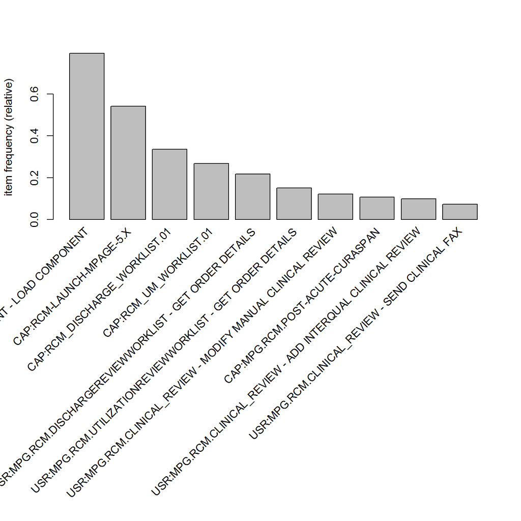

```r
itemFrequencyPlot(userTran, topN=10, names=TRUE)
```

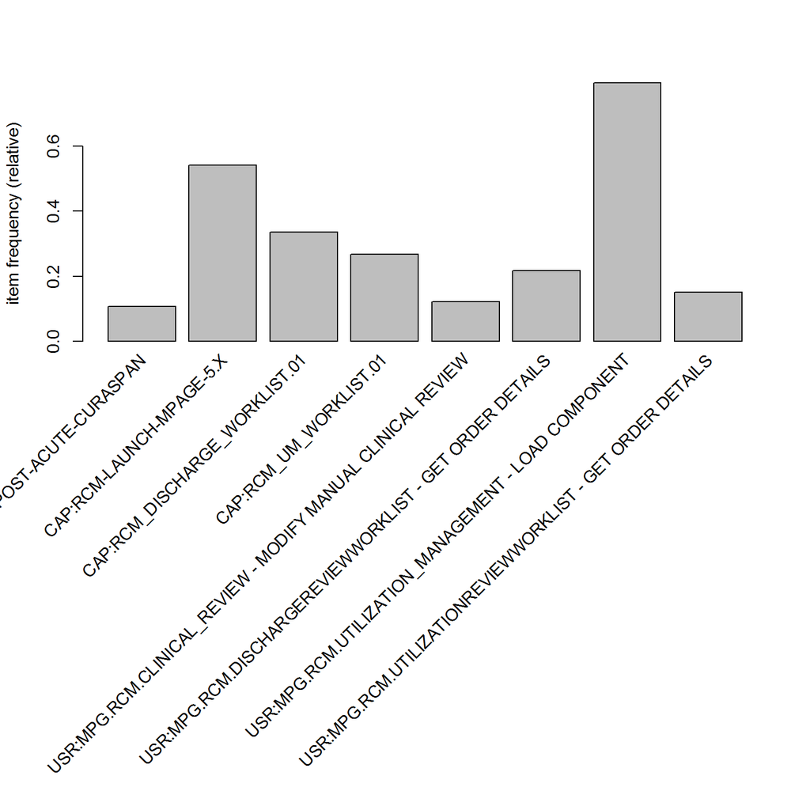

```r
itemFrequencyPlot(userTran, support = 0.1)
```

The sample image show some timers were used frequently while others were not used at all.

[figure not shown]

```r
image(userTran)
```

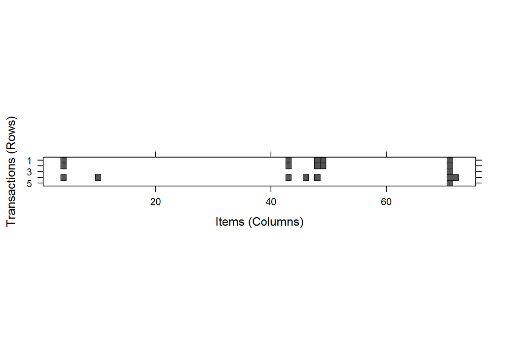

```r
image(userTran[1:5])
```

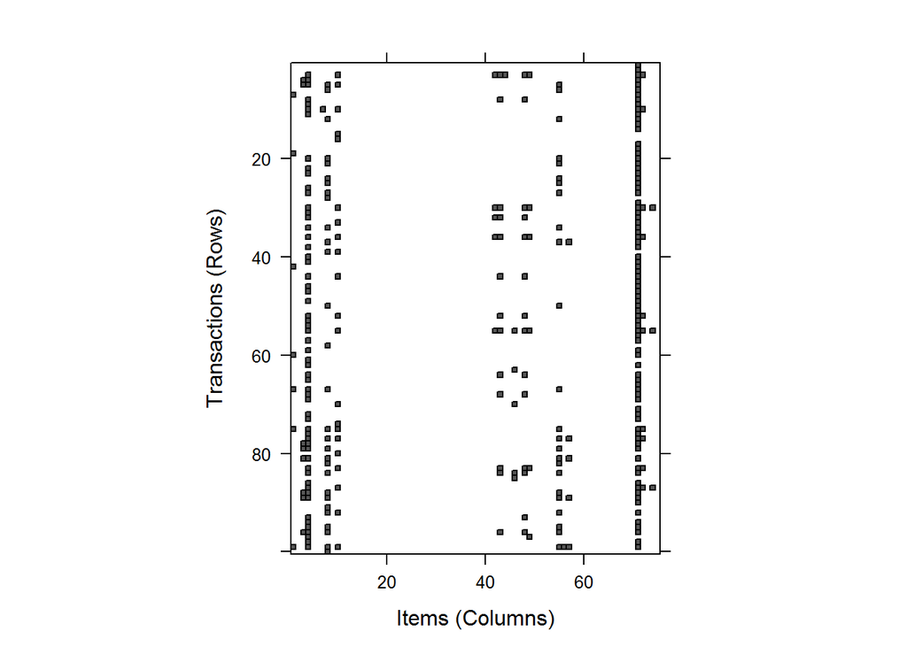

```r
image(sample(userTran, 100))
```

```r
summary(userTran)
```

```
## transactions as itemMatrix in sparse format with
##  11375 rows (elements/itemsets/transactions) and
##  75 columns (items) and a density of 0.04062828
##
## most frequent items:
##     USR:MPG.RCM.UTILIZATION_MANAGEMENT - LOAD COMPONENT
##                                                    9043
##                                CAP:RCM-LAUNCH-MPAGE-5.X
##                                                    6154
##                           CAP:RCM_DISCHARGE_WORKLIST.01
##                                                    3823
##                                  CAP:RCM_UM_WORKLIST.01
##                                                    3044
## USR:MPG.RCM.DISCHARGEREVIEWWORKLIST - GET ORDER DETAILS
##                                                    2467
##                                                 (Other)
##                                                   10130
##
## element (itemset/transaction) length distribution:
## sizes
##    1    2    3    4    5    6    7    8    9   10   11   12   13   14   15
## 3611 3244  978  868  951  531  396  331  231  139   50   20    9    2    2
##   18   27   28   29   31   32   35   36   37
##    1    1    3    1    1    2    1    1    1
##
##    Min. 1st Qu.  Median    Mean 3rd Qu.    Max.
##   1.000   1.000   2.000   3.047   4.000  37.000
##
## includes extended item information - examples:
##                                labels
## 1     CAP:MPG.RCM.POST-ACUTE-CURASPAN
## 2 CAP:MPG.RCM.RECOMMENDED DISPOSITION
## 3        CAP:RCM-LAUNCH-ENSOCARE-SHA2
```

Run Apriori on user transaction.

```r
userTranRules <- apriori(userTran, parameter = list(support = 0.1, confidence = 0.9, minlen = 2))
```

```
## Apriori
##
## Parameter specification:
##  confidence minval smax arem  aval originalSupport maxtime support minlen
##         0.9    0.1    1 none FALSE            TRUE       5     0.1      2
##  maxlen target   ext
##      10  rules FALSE
##
## Algorithmic control:
##  filter tree heap memopt load sort verbose
##     0.1 TRUE TRUE  FALSE TRUE    2    TRUE
##
## Absolute minimum support count: 1137
##
## set item appearances ...[0 item(s)] done [0.00s].
## set transactions ...[75 item(s), 11375 transaction(s)] done [0.00s].
## sorting and recoding items ... [8 item(s)] done [0.00s].
## creating transaction tree ... done [0.00s].
## checking subsets of size 1 2 3 4 done [0.00s].
## writing ... [31 rule(s)] done [0.00s].
## creating S4 object  ... done [0.00s].
```

```r
print(userTranRules)
```

```
## set of 31 rules
```

```r
summary(userTranRules)
```

```
## set of 31 rules
##
## rule length distribution (lhs + rhs):sizes
##  2  3  4
##  9 16  6
##
##    Min. 1st Qu.  Median    Mean 3rd Qu.    Max.
##   2.000   2.000   3.000   2.903   3.000   4.000
##
## summary of quality measures:
##     support         confidence          lift
##  Min.   :0.1057   Min.   :0.9087   Min.   :1.195
##  1st Qu.:0.1361   1st Qu.:0.9500   1st Qu.:1.248
##  Median :0.1444   Median :0.9924   Median :1.680
##  Mean   :0.1658   Mean   :0.9754   Mean   :2.180
##  3rd Qu.:0.1641   3rd Qu.:0.9967   3rd Qu.:2.958
##  Max.   :0.5334   Max.   :1.0000   Max.   :4.355
##
## mining info:
##      data ntransactions support confidence
##  userTran         11375     0.1        0.9
```

```r
userTranRules_sorted <-sort(userTranRules, by = c("lift", "confidence"))
kable(as(userTranRules_sorted, "data.frame"))
```

|  | rules | support | confidence | lift |
| --- | --- | --- | --- | --- |
| 31 | {CAP:RCM-LAUNCH-MPAGE-5.X,CAP:RCM_DISCHARGE_WORKLIST.01,USR:MPG.RCM.UTILIZATION_MANAGEMENT - LOAD COMPONENT} => {USR:MPG.RCM.DISCHARGEREVIEWWORKLIST - GET ORDER DETAILS} | 0.1617582 | 0.9445585 | 4.355230 |
| 19 | {CAP:RCM-LAUNCH-MPAGE-5.X,CAP:RCM_DISCHARGE_WORKLIST.01} => {USR:MPG.RCM.DISCHARGEREVIEWWORKLIST - GET ORDER DETAILS} | 0.1629890 | 0.9439919 | 4.352618 |
| 22 | {CAP:RCM_DISCHARGE_WORKLIST.01,USR:MPG.RCM.UTILIZATION_MANAGEMENT - LOAD COMPONENT} => {USR:MPG.RCM.DISCHARGEREVIEWWORKLIST - GET ORDER DETAILS} | 0.2048352 | 0.9224070 | 4.253093 |
| 4 | {USR:MPG.RCM.UTILIZATIONREVIEWWORKLIST - GET ORDER DETAILS} => {CAP:RCM_UM_WORKLIST.01} | 0.1501538 | 1.0000000 | 3.736859 |
| 13 | {CAP:RCM-LAUNCH-MPAGE-5.X,USR:MPG.RCM.UTILIZATIONREVIEWWORKLIST - GET ORDER DETAILS} => {CAP:RCM_UM_WORKLIST.01} | 0.1364396 | 1.0000000 | 3.736859 |
| 15 | {USR:MPG.RCM.UTILIZATION_MANAGEMENT - LOAD COMPONENT,USR:MPG.RCM.UTILIZATIONREVIEWWORKLIST - GET ORDER DETAILS} => {CAP:RCM_UM_WORKLIST.01} | 0.1443516 | 1.0000000 | 3.736859 |
| 28 | {CAP:RCM-LAUNCH-MPAGE-5.X,USR:MPG.RCM.UTILIZATION_MANAGEMENT - LOAD COMPONENT,USR:MPG.RCM.UTILIZATIONREVIEWWORKLIST - GET ORDER DETAILS} => {CAP:RCM_UM_WORKLIST.01} | 0.1360879 | 1.0000000 | 3.736859 |
| 7 | {USR:MPG.RCM.DISCHARGEREVIEWWORKLIST - GET ORDER DETAILS} => {CAP:RCM_DISCHARGE_WORKLIST.01} | 0.2156484 | 0.9943251 | 2.958527 |
| 21 | {USR:MPG.RCM.DISCHARGEREVIEWWORKLIST - GET ORDER DETAILS,USR:MPG.RCM.UTILIZATION_MANAGEMENT - LOAD COMPONENT} => {CAP:RCM_DISCHARGE_WORKLIST.01} | 0.2048352 | 0.9940273 | 2.957641 |
| 18 | {CAP:RCM-LAUNCH-MPAGE-5.X,USR:MPG.RCM.DISCHARGEREVIEWWORKLIST - GET ORDER DETAILS} => {CAP:RCM_DISCHARGE_WORKLIST.01} | 0.1629890 | 0.9935691 | 2.956278 |
| 30 | {CAP:RCM-LAUNCH-MPAGE-5.X,USR:MPG.RCM.DISCHARGEREVIEWWORKLIST - GET ORDER DETAILS,USR:MPG.RCM.UTILIZATION_MANAGEMENT - LOAD COMPONENT} => {CAP:RCM_DISCHARGE_WORKLIST.01} | 0.1617582 | 0.9935205 | 2.956133 |
| 2 | {USR:MPG.RCM.CLINICAL_REVIEW - MODIFY MANUAL CLINICAL REVIEW} => {CAP:RCM-LAUNCH-MPAGE-5.X} | 0.1207912 | 0.9970972 | 1.843026 |
| 11 | {USR:MPG.RCM.CLINICAL_REVIEW - MODIFY MANUAL CLINICAL REVIEW,USR:MPG.RCM.UTILIZATION_MANAGEMENT - LOAD COMPONENT} => {CAP:RCM-LAUNCH-MPAGE-5.X} | 0.1198242 | 0.9970739 | 1.842983 |
| 17 | {USR:MPG.RCM.UTILIZATION_MANAGEMENT - LOAD COMPONENT,USR:MPG.RCM.UTILIZATIONREVIEWWORKLIST - GET ORDER DETAILS} => {CAP:RCM-LAUNCH-MPAGE-5.X} | 0.1360879 | 0.9427527 | 1.742576 |
| 27 | {CAP:RCM_UM_WORKLIST.01,USR:MPG.RCM.UTILIZATION_MANAGEMENT - LOAD COMPONENT,USR:MPG.RCM.UTILIZATIONREVIEWWORKLIST - GET ORDER DETAILS} => {CAP:RCM-LAUNCH-MPAGE-5.X} | 0.1360879 | 0.9427527 | 1.742576 |
| 5 | {USR:MPG.RCM.UTILIZATIONREVIEWWORKLIST - GET ORDER DETAILS} => {CAP:RCM-LAUNCH-MPAGE-5.X} | 0.1364396 | 0.9086651 | 1.679569 |
| 12 | {CAP:RCM_UM_WORKLIST.01,USR:MPG.RCM.UTILIZATIONREVIEWWORKLIST - GET ORDER DETAILS} => {CAP:RCM-LAUNCH-MPAGE-5.X} | 0.1364396 | 0.9086651 | 1.679569 |
| 16 | {CAP:RCM-LAUNCH-MPAGE-5.X,USR:MPG.RCM.UTILIZATIONREVIEWWORKLIST - GET ORDER DETAILS} => {USR:MPG.RCM.UTILIZATION_MANAGEMENT - LOAD COMPONENT} | 0.1360879 | 0.9974227 | 1.254637 |
| 26 | {CAP:RCM-LAUNCH-MPAGE-5.X,CAP:RCM_UM_WORKLIST.01,USR:MPG.RCM.UTILIZATIONREVIEWWORKLIST - GET ORDER DETAILS} => {USR:MPG.RCM.UTILIZATION_MANAGEMENT - LOAD COMPONENT} | 0.1360879 | 0.9974227 | 1.254637 |
| 24 | {CAP:RCM-LAUNCH-MPAGE-5.X,CAP:RCM_UM_WORKLIST.01} => {USR:MPG.RCM.UTILIZATION_MANAGEMENT - LOAD COMPONENT} | 0.1651868 | 0.9962884 | 1.253210 |
| 1 | {CAP:MPG.RCM.POST-ACUTE-CURASPAN} => {USR:MPG.RCM.UTILIZATION_MANAGEMENT - LOAD COMPONENT} | 0.1056703 | 0.9925681 | 1.248531 |
| 23 | {CAP:RCM-LAUNCH-MPAGE-5.X,USR:MPG.RCM.DISCHARGEREVIEWWORKLIST - GET ORDER DETAILS} => {USR:MPG.RCM.UTILIZATION_MANAGEMENT - LOAD COMPONENT} | 0.1628132 | 0.9924973 | 1.248442 |
| 29 | {CAP:RCM-LAUNCH-MPAGE-5.X,CAP:RCM_DISCHARGE_WORKLIST.01,USR:MPG.RCM.DISCHARGEREVIEWWORKLIST - GET ORDER DETAILS} => {USR:MPG.RCM.UTILIZATION_MANAGEMENT - LOAD COMPONENT} | 0.1617582 | 0.9924488 | 1.248380 |
| 3 | {USR:MPG.RCM.CLINICAL_REVIEW - MODIFY MANUAL CLINICAL REVIEW} => {USR:MPG.RCM.UTILIZATION_MANAGEMENT - LOAD COMPONENT} | 0.1201758 | 0.9920174 | 1.247838 |
| 10 | {CAP:RCM-LAUNCH-MPAGE-5.X,USR:MPG.RCM.CLINICAL_REVIEW - MODIFY MANUAL CLINICAL REVIEW} => {USR:MPG.RCM.UTILIZATION_MANAGEMENT - LOAD COMPONENT} | 0.1198242 | 0.9919942 | 1.247809 |
| 25 | {CAP:RCM-LAUNCH-MPAGE-5.X,CAP:RCM_DISCHARGE_WORKLIST.01} => {USR:MPG.RCM.UTILIZATION_MANAGEMENT - LOAD COMPONENT} | 0.1712527 | 0.9918534 | 1.247632 |
| 9 | {CAP:RCM-LAUNCH-MPAGE-5.X} => {USR:MPG.RCM.UTILIZATION_MANAGEMENT - LOAD COMPONENT} | 0.5333626 | 0.9858629 | 1.240096 |
| 6 | {USR:MPG.RCM.UTILIZATIONREVIEWWORKLIST - GET ORDER DETAILS} => {USR:MPG.RCM.UTILIZATION_MANAGEMENT - LOAD COMPONENT} | 0.1443516 | 0.9613583 | 1.209272 |
| 14 | {CAP:RCM_UM_WORKLIST.01,USR:MPG.RCM.UTILIZATIONREVIEWWORKLIST - GET ORDER DETAILS} => {USR:MPG.RCM.UTILIZATION_MANAGEMENT - LOAD COMPONENT} | 0.1443516 | 0.9613583 | 1.209272 |
| 8 | {USR:MPG.RCM.DISCHARGEREVIEWWORKLIST - GET ORDER DETAILS} => {USR:MPG.RCM.UTILIZATION_MANAGEMENT - LOAD COMPONENT} | 0.2060659 | 0.9501419 | 1.195164 |
| 20 | {CAP:RCM_DISCHARGE_WORKLIST.01,USR:MPG.RCM.DISCHARGEREVIEWWORKLIST - GET ORDER DETAILS} => {USR:MPG.RCM.UTILIZATION_MANAGEMENT - LOAD COMPONENT} | 0.2048352 | 0.9498573 | 1.194806 |

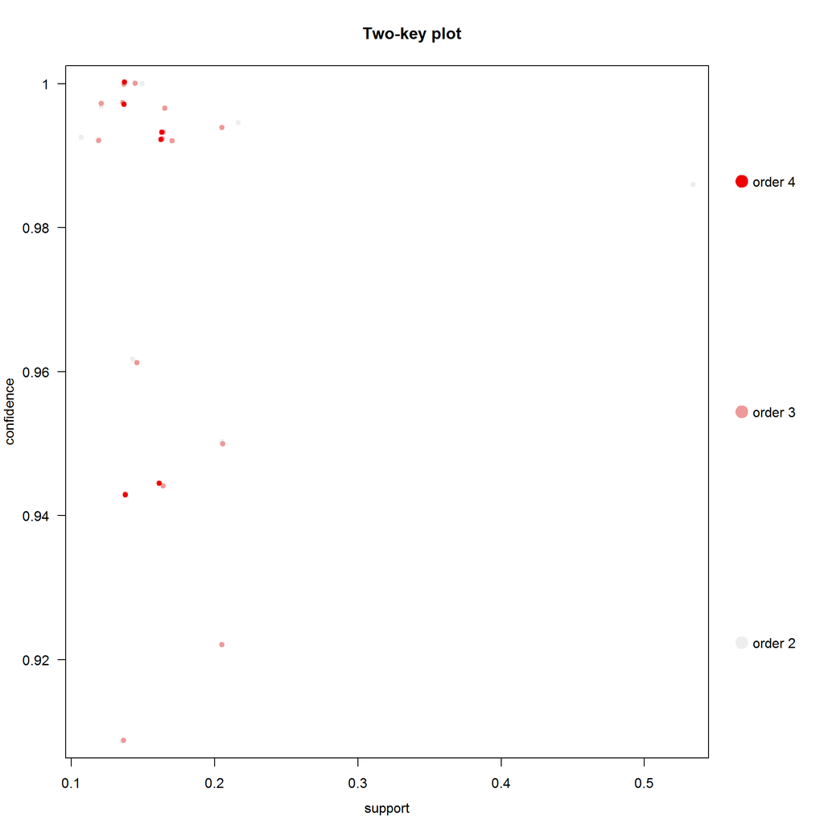

```r
plot(userTranRules_sorted, shading="order", control=list(main="Two-key plot"))
```

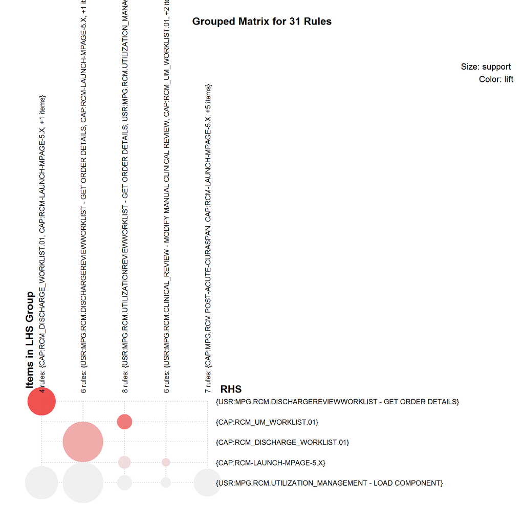

```r
plot(userTranRules_sorted, method="grouped", control=list(k=5))
```

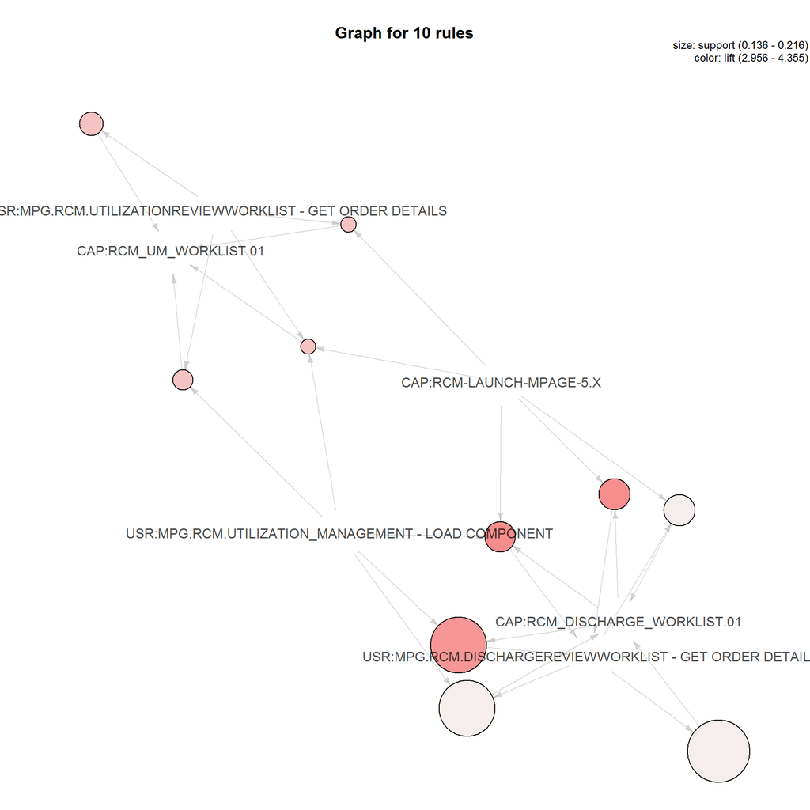

```r
plot(userTranRules_sorted[1:10], method="graph")
```

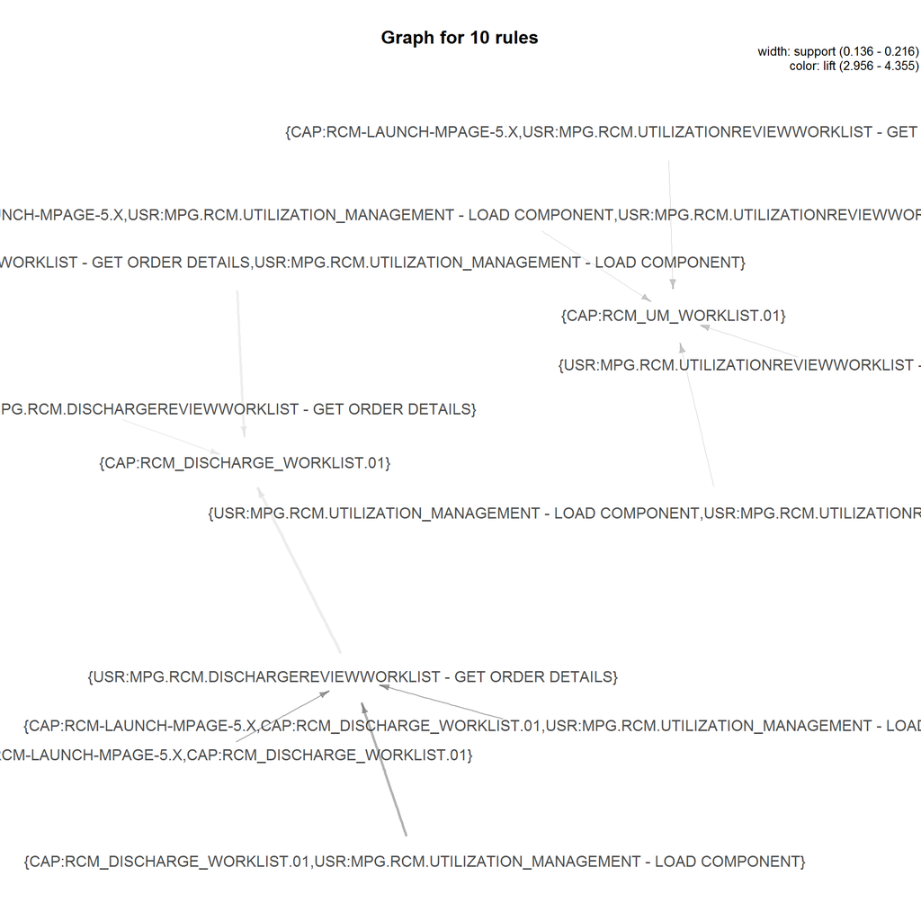

```r
plot(userTranRules_sorted[1:10], method="graph", control=list(type="itemsets"))
```

Only looking at clinical review related subset rules

```r
subsetRules <- subset(userTranRules_sorted, items %in% "USR:MPG.RCM.CLINICAL_REVIEW - MODIFY MANUAL CLINICAL REVIEW")
subsetRules_df <- as(subsetRules, "data.frame")
kable(subsetRules_df, caption = "USR:MPG.RCM.CLINICAL_REVIEW - MODIFY MANUAL CLINICAL REVIEW subset")
```

USR:MPG.RCM.CLINICAL_REVIEW - MODIFY MANUAL CLINICAL REVIEW subset

|  | rules | support | confidence | lift |
| --- | --- | --- | --- | --- |
| 2 | {USR:MPG.RCM.CLINICAL_REVIEW - MODIFY MANUAL CLINICAL REVIEW} => {CAP:RCM-LAUNCH-MPAGE-5.X} | 0.1207912 | 0.9970972 | 1.843026 |
| 11 | {USR:MPG.RCM.CLINICAL_REVIEW - MODIFY MANUAL CLINICAL REVIEW,USR:MPG.RCM.UTILIZATION_MANAGEMENT - LOAD COMPONENT} => {CAP:RCM-LAUNCH-MPAGE-5.X} | 0.1198242 | 0.9970739 | 1.842983 |
| 3 | {USR:MPG.RCM.CLINICAL_REVIEW - MODIFY MANUAL CLINICAL REVIEW} => {USR:MPG.RCM.UTILIZATION_MANAGEMENT - LOAD COMPONENT} | 0.1201758 | 0.9920174 | 1.247838 |
| 10 | {CAP:RCM-LAUNCH-MPAGE-5.X,USR:MPG.RCM.CLINICAL_REVIEW - MODIFY MANUAL CLINICAL REVIEW} => {USR:MPG.RCM.UTILIZATION_MANAGEMENT - LOAD COMPONENT} | 0.1198242 | 0.9919942 | 1.247809 |

### 3. KMean Clustering by user timer frequencies

We know users use a few of the timers much more than others. I want to create user profiles from user timer frequencies. First I need to create a sparse matrix of 11,375 user and 75 timers. I used cbind method to combine columns and rows. Then add frequencies from the user timer name table properties.

```r
#Create user timer frequency matrix
timer_user_prop <- as.data.frame(table(timer_user))
dim(timer_user_prop)
```

```
## [1] 853125      3
```

```r
#Combine to user timer name frequencies
userTimerSparse <- matrix(0, nrow = 11375, ncol = 75)
userTimerSparse[cbind(timer_user_prop$USERPRINCIPALS, timer_user_prop$TIMERNAME)] <- timer_user_prop$Freq;
dim(userTimerSparse)
```

```
## [1] 11375    75
```

```r
userTimerSparse_df <- as.data.frame(userTimerSparse)
colnames(userTimerSparse_df) <- unique(timer_user_prop$TIMERNAME)
rownames(userTimerSparse_df) <- unique(timer_user_prop$USERPRINCIPALS)
```

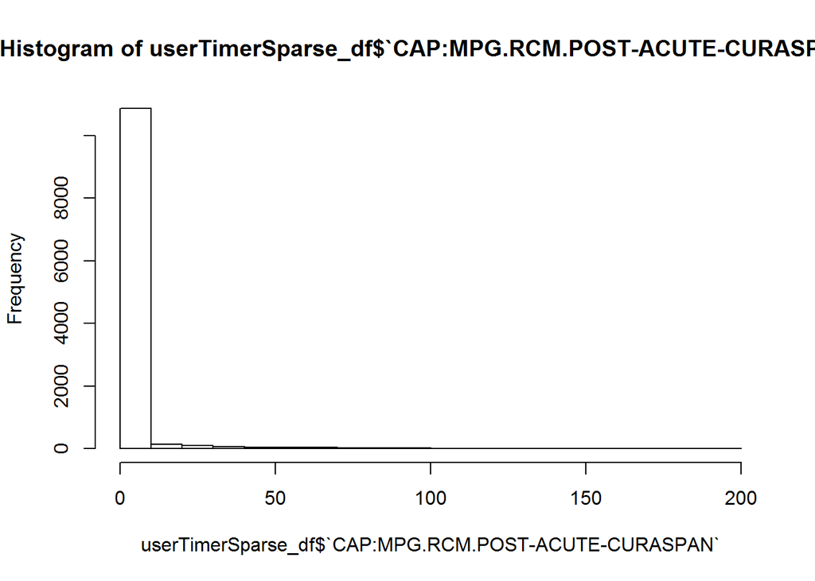

```r
hist(userTimerSparse_df$`CAP:MPG.RCM.POST-ACUTE-CURASPAN`)
```

```r
quantile(userTimerSparse_df$`CAP:MPG.RCM.POST-ACUTE-CURASPAN`,prob = seq(0, 1, length = 6), na.rm=TRUE)
```

```
##   0%  20%  40%  60%  80% 100%
##    0    0    0    0    0  200
```

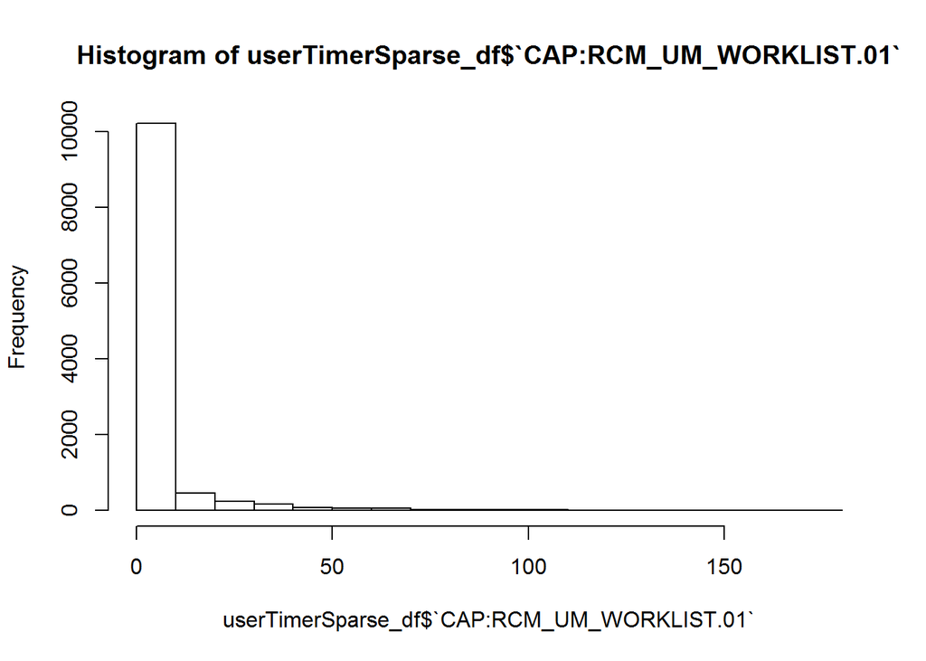

```r
hist(userTimerSparse_df$`CAP:RCM_UM_WORKLIST.01`)
```

```r
quantile(userTimerSparse_df$`CAP:RCM_UM_WORKLIST.01`,prob = seq(0, 1, length = 6), na.rm=TRUE)
```

```
##   0%  20%  40%  60%  80% 100%
##    0    0    0    0    3  178
```

```r
## Optimal cluster size k
user_clusters_optimal<-kmeansruns(userTimerSparse_df, krange=3:9) #finds the "best"" K between 3 and 9
user_clusters_optimal$bestk
```

```
## [1] 3
```

Method 1: Use the visualizations

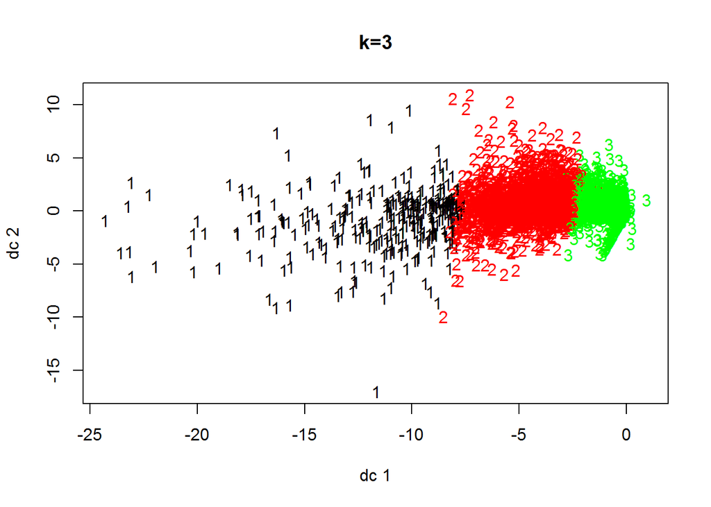

```r
set.seed(123)
user_clusters_3 <- kmeans(userTimerSparse_df, centers=3)
plotcluster(userTimerSparse_df, user_clusters_3$cluster, main="k=3")
```

```r
# Cluster size
user_clusters_3$size
```

```
## [1]  320 1951 9104
```

```r
# Within Sum of Squares
user_clusters_3$withinss
```

```
## [1]  7943627 12130230  8209613
```

```r
# Between Sum of Squares
user_clusters_3$betweenss
```

```
## [1] 57319638
```

```r
# Total Sum of Squares
user_clusters_3$totss
```

```
## [1] 85603107
```

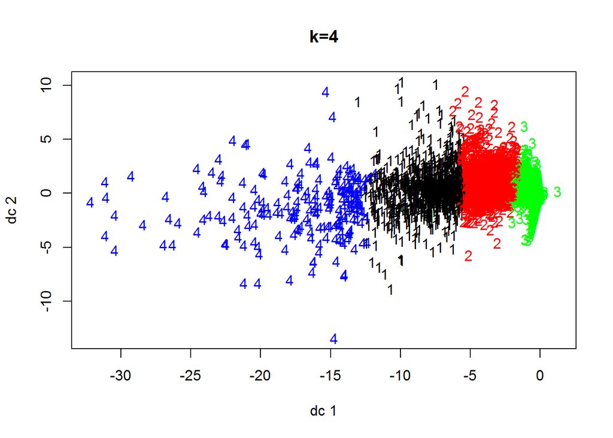

```r
set.seed(123)
user_clusters_4 <- kmeans(userTimerSparse_df, centers=4)
plotcluster(userTimerSparse_df, user_clusters_4$cluster, main="k=4")
```

```r
user_clusters_4$size
```

```
## [1]  971 2313 7878  213
```

```r
user_clusters_4$withinss
```

```
## [1] 7025267 6507058 3726017 5733090
```

```r
# Between Sum of Squares
user_clusters_4$betweenss
```

```
## [1] 62611676
```

```r
# Total Sum of Squares
user_clusters_4$totss
```

```
## [1] 85603107
```

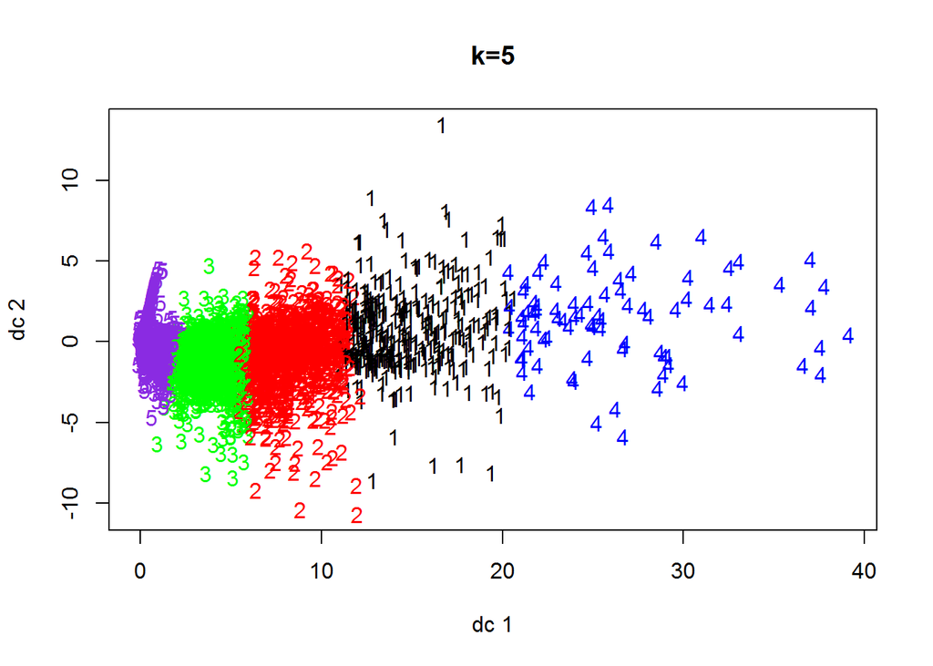

```r
set.seed(123)
user_clusters_5 <- kmeans(userTimerSparse_df, centers=5)
plotcluster(userTimerSparse_df, user_clusters_5$cluster, main="k=5")
```

```r
user_clusters_5$size
```

```
## [1]  334 1041 2349   84 7567
```

```r
user_clusters_5$withinss
```

```
## [1] 3450131 6141923 5207995 2726445 3135301
```

```r
# Between Sum of Squares
user_clusters_5$betweenss
```

```
## [1] 64941311
```

```r
# Total Sum of Squares
user_clusters_5$totss
```

```
## [1] 85603107
```

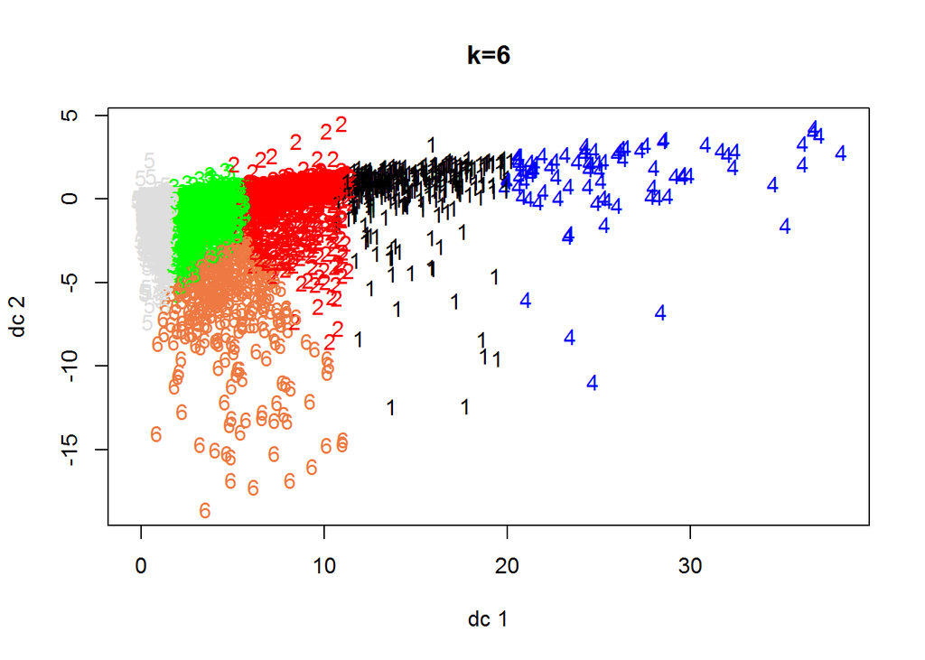

```r
set.seed(123)
user_clusters_6 <- kmeans(userTimerSparse_df, centers=6)
plotcluster(userTimerSparse_df, user_clusters_6$cluster, main="k=6")
```

```r
user_clusters_6$size
```

```
## [1]  324  940 2156   84 7532  339
```

```r
user_clusters_6$withinss
```

```
## [1] 3370118 4642378 3401456 2726445 3077036 1946932
```

```r
# Between Sum of Squares
user_clusters_6$betweenss
```

```
## [1] 66438743
```

```r
# Total Sum of Squares
user_clusters_6$totss
```

```
## [1] 85603107
```

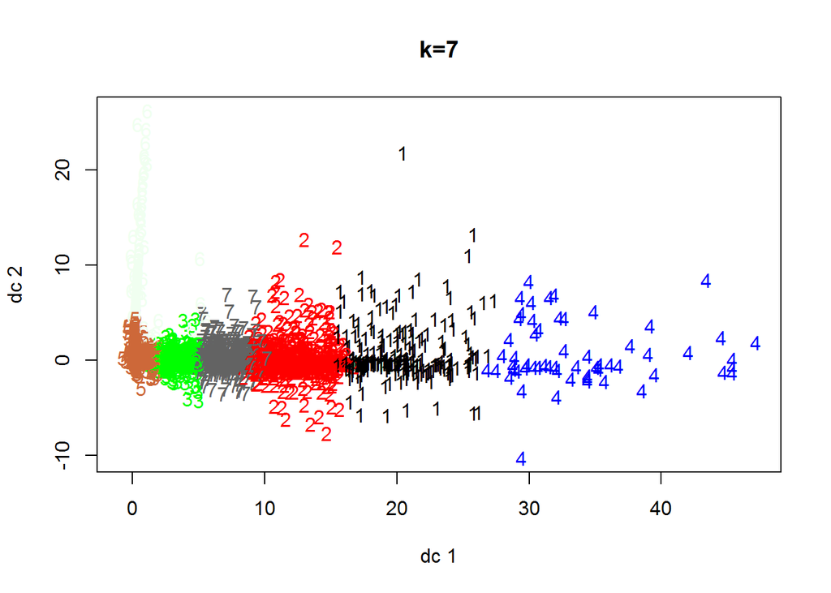

```r
set.seed(123)
user_clusters_7 <- kmeans(userTimerSparse_df, centers=7)
plotcluster(userTimerSparse_df, user_clusters_7$cluster, main="k=7")
```

```r
user_clusters_7$size
```

```
## [1]  233  684 2203   59 6902  141 1153
```

```r
user_clusters_7$withinss
```

```
## [1] 2781028.9 4145082.1 2912795.0 2077319.7 1735119.2  244774.3 4749683.4
```

```r
# Between Sum of Squares
user_clusters_7$betweenss
```

```
## [1] 66957305
```

```r
# Total Sum of Squares
user_clusters_7$totss
```

```
## [1] 85603107
```

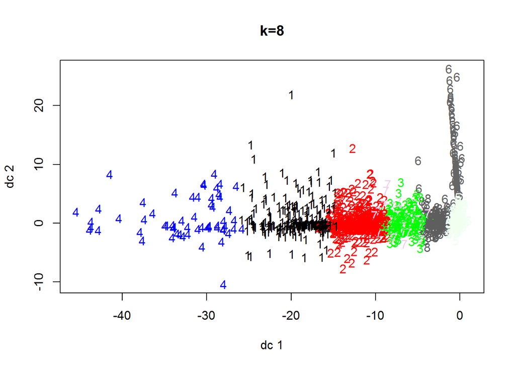

```r
set.seed(123)
user_clusters_8 <- kmeans(userTimerSparse_df, centers=8)
plotcluster(userTimerSparse_df, user_clusters_8$cluster, main="k=8")
```

```r
user_clusters_8$size
```

```
## [1]  236  683  938   60 6686  135  513 2124
```

```r
user_clusters_8$withinss
```

```
## [1] 2802228.7 3958434.6 2270093.2 2100407.3 1567277.5  229804.7 2473125.3
## [8] 1951881.9
```

```r
# Between Sum of Squares
user_clusters_8$betweenss
```

```
## [1] 68249854
```

```r
# Total Sum of Squares
user_clusters_8$totss
```

```
## [1] 85603107
```

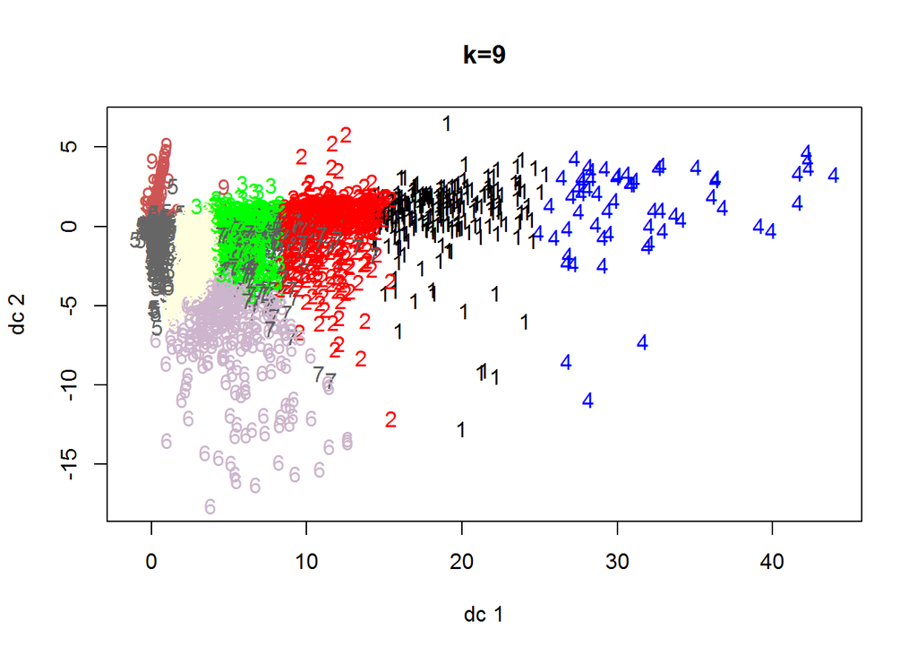

```r
set.seed(123)
user_clusters_9 <- kmeans(userTimerSparse_df, centers=9)
plotcluster(userTimerSparse_df, user_clusters_9$cluster, main="k=9")
```

```r
user_clusters_9$size
```

```
## [1]  225  585  855   59 6717  266  427 2106  135
```

```r
user_clusters_9$withinss
```

```
## [1] 2675938.4 3164565.6 1710714.6 2077319.7 1538205.3 1506742.6 1469544.2
## [8] 1878431.9  229804.7
```

```r
# Between Sum of Squares
user_clusters_9$betweenss
```

```
## [1] 69351840
```

```r
# Total Sum of Squares
user_clusters_9$totss
```

```
## [1] 85603107
```

Method 2: Examine the betweenss and withinss ratios. Separation is determined by between sum of square / total sum of square k = 9 has the highest between sum of square which means most separation. clusters3<- user_clusters_3$betweenss/user_clusters_3$totss

```r
clusters3<- user_clusters_3$betweenss/user_clusters_3$totss
clusters4<- user_clusters_4$betweenss/user_clusters_4$totss
clusters5<- user_clusters_5$betweenss/user_clusters_5$totss
clusters6<- user_clusters_6$betweenss/user_clusters_6$totss
clusters7<- user_clusters_7$betweenss/user_clusters_7$totss
clusters8<- user_clusters_8$betweenss/user_clusters_8$totss
clusters9<- user_clusters_9$betweenss/user_clusters_9$totss

betweenss.metric <- c(clusters3, clusters4, clusters5, clusters6, clusters7, clusters8, clusters9)
print(betweenss.metric) # Look for a ratio that is closer to 1.
```

```
## [1] 0.6695976 0.7314183 0.7586326 0.7761254 0.7821831 0.7972824 0.8101556
```

Cluster Cohesion within sum of square / total sum of square ratio k = 9 has the lowest within sum of square which means most cohesion.

```r
clusters3<- user_clusters_3$tot.withinss/user_clusters_3$totss
clusters4<- user_clusters_4$tot.withinss/user_clusters_4$totss
clusters5<- user_clusters_5$tot.withinss/user_clusters_5$totss
clusters6<- user_clusters_6$tot.withinss/user_clusters_6$totss
clusters7<- user_clusters_7$tot.withinss/user_clusters_7$totss
clusters8<- user_clusters_8$tot.withinss/user_clusters_8$totss
clusters9<- user_clusters_9$tot.withinss/user_clusters_9$totss

totwithinss <- c(clusters3, clusters4, clusters5, clusters6, clusters7, clusters8, clusters9)
print(totwithinss) # Look for a ratio that is closer to 1.
```

```
## [1] 0.3304024 0.2685817 0.2413674 0.2238746 0.2178169 0.2027176 0.1898444
```

Method 3: Use the “Elbow Method” from graphs of cohesiveness and distinctiveness

```r
wss <- NULL
# for one cluster the withiness is equals to 85608131 (sum of variance on all items).
wss[1] <- (nrow(userTimerSparse_df)-1)*sum(apply(userTimerSparse_df, 2, var))
# test within ss from 2 to 9 clusters.
# elbow point at K = 3, 6
set.seed(123)
for (i in 1:9)
  wss[i] <- sum(kmeans(userTimerSparse_df, centers=i)$withinss)
```

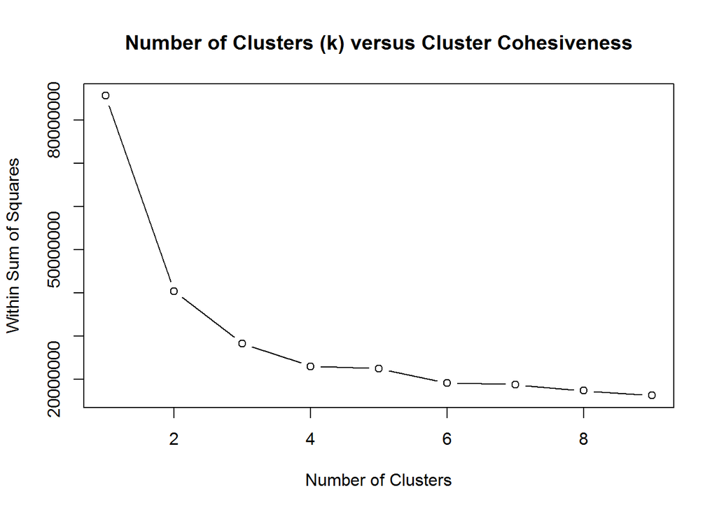

```r
# Within Sum of Squares plot
plot(1:9, wss, type="b", xlab="Number of Clusters", ylab="Within Sum of Squares",
     main = "Number of Clusters (k) versus Cluster Cohesiveness")
```

```r
bss <- NULL
# for one cluster the betweeness is equals to 85608131 (sum of variance on all items).
bss[1] <- (nrow(userTimerSparse_df)-1)*sum(apply(userTimerSparse_df, 2, var))
# test between ss from 2 to 9 clusters.
# elbow point at K = 3, 6
set.seed(123)
for (i in 1:9)
  bss[i] <- sum(kmeans(userTimerSparse_df, centers=i)$betweenss)
```

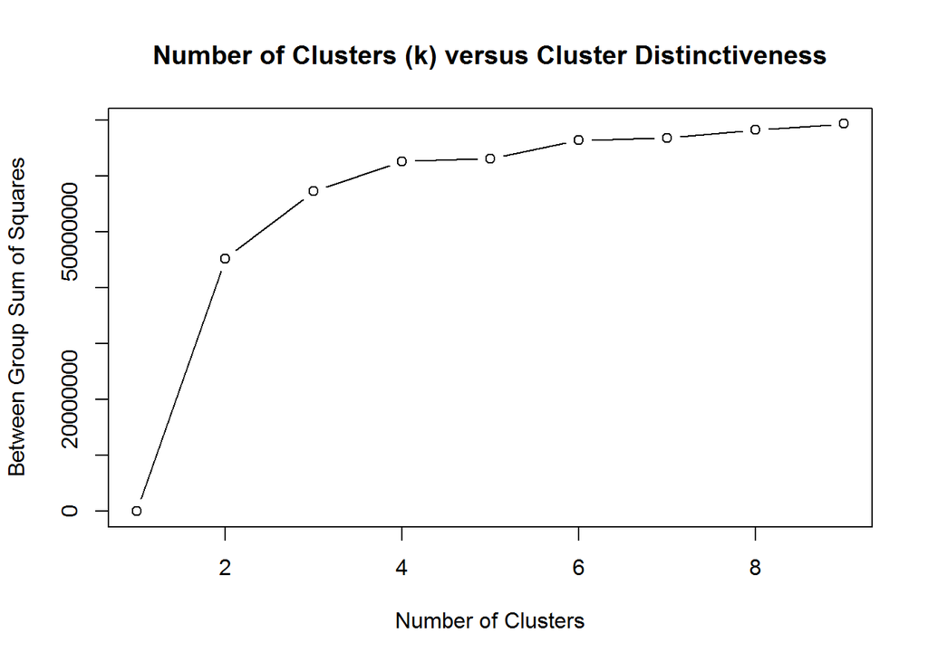

```r
# Between Sum of Squares plot
plot(1:9, bss, type="b", xlab="Number of Clusters",
     ylab="Between Group Sum of Squares", main = "Number of Clusters (k) versus Cluster Distinctiveness")
```

Method 4: Using Calinski-Harabasz pseudo F-statistic

K = 3 has the larest pseudo-F statistic

```r
#help(index.G1) #read the ../doc/indexG1_details.pdf
a<-index.G1(userTimerSparse_df, user_clusters_3$cluster, centrotypes = "centroids")
b<-index.G1(userTimerSparse_df, user_clusters_4$cluster, centrotypes = "centroids")
c<-index.G1(userTimerSparse_df, user_clusters_5$cluster, centrotypes = "centroids")
d<-index.G1(userTimerSparse_df, user_clusters_6$cluster, centrotypes = "centroids")
e<-index.G1(userTimerSparse_df, user_clusters_7$cluster, centrotypes = "centroids")
f<-index.G1(userTimerSparse_df, user_clusters_8$cluster, centrotypes = "centroids")
g<-index.G1(userTimerSparse_df, user_clusters_9$cluster, centrotypes = "centroids")

pseudoF<-c(a,b,c,d,e,f,g)
pseudoF
```

```
## [1] 11523.320 10322.068  8934.154  7882.777  6803.771  6386.584  6063.012
```

```r
## Pick k = 3
## Creating an Aggregate Profile for Our Clusters
user_clusters_3$size #Get the size of each cluster
```

```
## [1]  320 1951 9104
```

```r
Clusters_3<-data.frame(t(user_clusters_3$centers)) #Transpose for easier reading
## We can sort the centroids for each cluster.
kable(Clusters_3[order(-Clusters_3$X1), ])
```

|  | X1 | X2 | X3 |
| --- | --- | --- | --- |
| USR:MPG.RCM.UTILIZATION_MANAGEMENT - LOAD COMPONENT | 308.484375 | 115.2726807 | 14.4309095 |
| CAP:RCM-LAUNCH-MPAGE-5.X | 186.337500 | 69.8293183 | 6.1307118 |
| USR:MPG.RCM.UTILIZATIONREVIEWWORKLIST - GET ORDER DETAILS | 38.831250 | 10.7391081 | 0.6777241 |
| CAP:RCM_UM_WORKLIST.01 | 34.484375 | 8.8903127 | 2.1626757 |
| USR:MPG.RCM.CLINICAL_REVIEW - MODIFY MANUAL CLINICAL REVIEW | 31.859375 | 7.7196310 | 0.3133787 |
| USR:MPG.RCM.CLINICAL_REVIEW - ADD INTERQUAL CLINICAL REVIEW | 21.800000 | 4.9010764 | 0.1843146 |
| USR:MPG.RCM.CLINICAL_REVIEW - SEND CLINICAL FAX | 10.853125 | 2.1911840 | 0.0638181 |
| USR:MPG.RCM.DISCHARGEREVIEWWORKLIST - GET ORDER DETAILS | 7.512500 | 13.0922604 | 2.7348418 |
| USR:MPG.RCM.CLINICAL_REVIEW - ADD MANUAL CLINICAL REVIEW | 6.103125 | 1.6007176 | 0.0536028 |
| CAP:RCM_DISCHARGE_WORKLIST.01 | 5.734375 | 8.9128652 | 3.0135105 |
| USR:MPG.RCM.CLINICAL_REVIEW - ADD CLINICAL REVIEW ADDENDUMS | 4.837500 | 0.7293696 | 0.0173550 |
| CAP:MPG.RCM.POST-ACUTE-CURASPAN | 3.862500 | 7.0891850 | 1.1062170 |
| USR:MPG.RCM.CLINICAL_REVIEW - LOAD INTERQUAL CLINICAL REVIEW | 1.543750 | 0.7165556 | 0.1684974 |
| CAP:RCM-LAUNCH-ENSOCARE-SHA2 | 1.409375 | 1.5715018 | 0.2236380 |
| USR:MPG.RCM.UTILIZATIONREVIEWWORKLIST - GET WORKLIST ITEM DETAILS | 0.584375 | 0.1932342 | 0.0238357 |
| USR:MPG.RCM.POST_ACUTE_SERVICES - SEND XR PACKET | 0.181250 | 0.0256279 | 0.0038445 |
| CAP:RCM_DENIED_DAYS_WORKLIST.01 | 0.062500 | 0.0420297 | 0.0788664 |
| USR:MPG.RCM.DISCHARGEREVIEWWORKLIST - GET WORKLIST ITEM DETAILS | 0.059375 | 0.2080984 | 0.0637083 |
| USR:MPG.RCM.POST_ACUTE_PLACEMENT - SEND XR PACKET | 0.040625 | 0.0804716 | 0.0150483 |
| CAP:RCM_APPEALS_WORKLIST.01 | 0.025000 | 0.0164018 | 0.0191125 |
| USR:MPG.RCM.UTILIZATIONREVIEWWORKLIST - GET READMISSION RISK DETAILS | 0.009375 | 0.0030753 | 0.0004394 |
| USR:MPG.RCM.DISCHARGEREVIEWWORKLIST - GET READMISSION RISK DETAILS | 0.003125 | 0.0046130 | 0.0037346 |
| CAP:MPG.RCM.RECOMMENDED DISPOSITION | 0.000000 | 0.0087135 | 0.0030756 |
| CAP:RCM_CDI_FINAL_DRG_01 | 0.000000 | 0.0000000 | 0.0006591 |
| CAP:RCM_NAVI_SEND_CCD_01 | 0.000000 | 0.0000000 | 0.0679921 |
| ENG:MPG.RCM.AVOID_DAYS | 0.000000 | 0.0000000 | 0.0123023 |
| ENG:MPG.RCM.CARE_MGMT | 0.000000 | 0.0000000 | 0.0205404 |
| ENG:MPG.RCM.CLINICAL_REVIEW | 0.000000 | 0.0000000 | 0.0237258 |
| ENG:MPG.RCM.CLINICAL_REVIEW - ADD MANUAL CLINICAL REVIEW | 0.000000 | 0.0000000 | 0.0001098 |
| ENG:MPG.RCM.CLINICAL_REVIEW - GET PAYER COMMUNICATION INFO | 0.000000 | 0.0000000 | 0.0006591 |
| ENG:MPG.RCM.CLINICAL_REVIEW - MODIFY MANUAL CLINICAL REVIEW | 0.000000 | 0.0000000 | 0.0003295 |
| ENG:MPG.RCM.CLINICAL_REVIEW - OPEN SECONDARY REVIEW DIALOG | 0.000000 | 0.0000000 | 0.0004394 |
| ENG:MPG.RCM.CLINICAL_REVIEW - SAVE TO CAMM | 0.000000 | 0.0000000 | 0.0001098 |
| ENG:MPG.RCM.COMMON | 0.000000 | 0.0000000 | 0.0071397 |
| ENG:MPG.RCM.COMMON - CREATE OAUTH SESSION | 0.000000 | 0.0000000 | 0.0004394 |
| ENG:MPG.RCM.COMMON - MAKE WEB SERVICE CALL | 0.000000 | 0.0000000 | 0.0008787 |
| ENG:MPG.RCM.CURASPAN | 0.000000 | 0.0000000 | 0.0090070 |
| ENG:MPG.RCM.CURASPAN - GET UPLOADS | 0.000000 | 0.0000000 | 0.0027460 |
| ENG:MPG.RCM.DENIED_DAYS | 0.000000 | 0.0000000 | 0.0141696 |
| ENG:MPG.RCM.DISCHARGE_PLANNING | 0.000000 | 0.0000000 | 0.0027460 |
| ENG:MPG.RCM.DOC_REVIEW | 0.000000 | 0.0000000 | 0.0144991 |
| ENG:MPG.RCM.INS_INFO | 0.000000 | 0.0000000 | 0.0081283 |
| ENG:MPG.RCM.NOTES_LIST | 0.000000 | 0.0000000 | 0.0052724 |
| ENG:MPG.RCM.PACKET_FORM | 0.000000 | 0.0000000 | 0.0081283 |
| ENG:MPG.RCM.POST_ACUTE_PLACEMENT | 0.000000 | 0.0000000 | 0.0096661 |
| ENG:MPG.RCM.POST_ACUTE_SERVICES | 0.000000 | 0.0000000 | 0.0119728 |
| ENG:MPG.RCM.READMISSION | 0.000000 | 0.0000000 | 0.0058216 |
| ENG:MPG.RCM.SEARCH | 0.000000 | 0.0000000 | 0.0035149 |
| ENG:MPG.RCM.VISIT_INFO | 0.000000 | 0.0000000 | 0.0050527 |
| ENG:RCM.ASSIGNMENTWORKLIST | 0.000000 | 0.0000000 | 0.0002197 |
| ENG:RCM.DOCUMENTREVIEWWORKLIST | 0.000000 | 0.0000000 | 0.0045035 |
| ENG:RCM.UMASSIGNMENTWORKLIST | 0.000000 | 0.0000000 | 0.0025264 |
| USR:MPG.RCM.AVOID_DAYS - LOAD COMPONENT | 0.000000 | 0.0000000 | 0.0102153 |
| USR:MPG.RCM.CARE_MGMT | 0.000000 | 0.0000000 | 0.0030756 |
| USR:MPG.RCM.CARE_MGMT - LOAD COMPONENT | 0.000000 | 0.0000000 | 0.0144991 |
| USR:MPG.RCM.CLINICAL_REVIEW | 0.000000 | 0.0000000 | 0.0075791 |
| USR:MPG.RCM.CLINICAL_REVIEW - LOAD COMPONENT | 0.000000 | 0.0000000 | 0.0132909 |
| USR:MPG.RCM.CLINICAL_REVIEW - MODIFY INTERQUAL CLINICAL REVIEW | 0.000000 | 0.0000000 | 0.0002197 |
| USR:MPG.RCM.CURASPAN | 0.000000 | 0.0000000 | 0.0004394 |
| USR:MPG.RCM.CURASPAN - LOAD COMPONENT | 0.000000 | 0.0000000 | 0.0070299 |
| USR:MPG.RCM.DENIED_DAYS | 0.000000 | 0.0000000 | 0.0020870 |
| USR:MPG.RCM.DENIED_DAYS - LOAD COMPONENT | 0.000000 | 0.0000000 | 0.0112039 |
| USR:MPG.RCM.DISCHARGE_PLANNING - LOAD COMPONENT | 0.000000 | 0.0000000 | 0.0036248 |
| USR:MPG.RCM.DOC_REVIEW - LOAD COMPONENT | 0.000000 | 0.0000000 | 0.0112039 |
| USR:MPG.RCM.INS_INFO - LOAD COMPONENT | 0.000000 | 0.0000000 | 0.0142794 |
| USR:MPG.RCM.NOTES_LIST - LOAD COMPONENT | 0.000000 | 0.0000000 | 0.0070299 |
| USR:MPG.RCM.PACKET_FORM | 0.000000 | 0.0000000 | 0.0035149 |
| USR:MPG.RCM.POST_ACUTE_PLACEMENT | 0.000000 | 0.0000000 | 0.0005492 |
| USR:MPG.RCM.POST_ACUTE_PLACEMENT - LOAD COMPONENT | 0.000000 | 0.0000000 | 0.0079086 |
| USR:MPG.RCM.POST_ACUTE_SERVICES | 0.000000 | 0.0000000 | 0.0027460 |
| USR:MPG.RCM.POST_ACUTE_SERVICES - LOAD COMPONENT | 0.000000 | 0.0000000 | 0.0090070 |
| USR:MPG.RCM.READMISSION | 0.000000 | 0.0000000 | 0.0012083 |
| USR:MPG.RCM.READMISSION - LOAD COMPONENT | 0.000000 | 0.0000000 | 0.0058216 |
| USR:MPG.RCM.SEARCH | 0.000000 | 0.0000000 | 0.1853032 |
| USR:MPG.RCM.VISIT_INFO - LOAD COMPONENT | 0.000000 | 0.0000000 | 0.0077988 |

```r
kable(Clusters_3[order(-Clusters_3$X2), ])
```

|  | X1 | X2 | X3 |
| --- | --- | --- | --- |
| USR:MPG.RCM.UTILIZATION_MANAGEMENT - LOAD COMPONENT | 308.484375 | 115.2726807 | 14.4309095 |
| CAP:RCM-LAUNCH-MPAGE-5.X | 186.337500 | 69.8293183 | 6.1307118 |
| USR:MPG.RCM.DISCHARGEREVIEWWORKLIST - GET ORDER DETAILS | 7.512500 | 13.0922604 | 2.7348418 |
| USR:MPG.RCM.UTILIZATIONREVIEWWORKLIST - GET ORDER DETAILS | 38.831250 | 10.7391081 | 0.6777241 |
| CAP:RCM_DISCHARGE_WORKLIST.01 | 5.734375 | 8.9128652 | 3.0135105 |
| CAP:RCM_UM_WORKLIST.01 | 34.484375 | 8.8903127 | 2.1626757 |
| USR:MPG.RCM.CLINICAL_REVIEW - MODIFY MANUAL CLINICAL REVIEW | 31.859375 | 7.7196310 | 0.3133787 |
| CAP:MPG.RCM.POST-ACUTE-CURASPAN | 3.862500 | 7.0891850 | 1.1062170 |
| USR:MPG.RCM.CLINICAL_REVIEW - ADD INTERQUAL CLINICAL REVIEW | 21.800000 | 4.9010764 | 0.1843146 |
| USR:MPG.RCM.CLINICAL_REVIEW - SEND CLINICAL FAX | 10.853125 | 2.1911840 | 0.0638181 |
| USR:MPG.RCM.CLINICAL_REVIEW - ADD MANUAL CLINICAL REVIEW | 6.103125 | 1.6007176 | 0.0536028 |
| CAP:RCM-LAUNCH-ENSOCARE-SHA2 | 1.409375 | 1.5715018 | 0.2236380 |
| USR:MPG.RCM.CLINICAL_REVIEW - ADD CLINICAL REVIEW ADDENDUMS | 4.837500 | 0.7293696 | 0.0173550 |
| USR:MPG.RCM.CLINICAL_REVIEW - LOAD INTERQUAL CLINICAL REVIEW | 1.543750 | 0.7165556 | 0.1684974 |
| USR:MPG.RCM.DISCHARGEREVIEWWORKLIST - GET WORKLIST ITEM DETAILS | 0.059375 | 0.2080984 | 0.0637083 |
| USR:MPG.RCM.UTILIZATIONREVIEWWORKLIST - GET WORKLIST ITEM DETAILS | 0.584375 | 0.1932342 | 0.0238357 |
| USR:MPG.RCM.POST_ACUTE_PLACEMENT - SEND XR PACKET | 0.040625 | 0.0804716 | 0.0150483 |
| CAP:RCM_DENIED_DAYS_WORKLIST.01 | 0.062500 | 0.0420297 | 0.0788664 |
| USR:MPG.RCM.POST_ACUTE_SERVICES - SEND XR PACKET | 0.181250 | 0.0256279 | 0.0038445 |
| CAP:RCM_APPEALS_WORKLIST.01 | 0.025000 | 0.0164018 | 0.0191125 |
| CAP:MPG.RCM.RECOMMENDED DISPOSITION | 0.000000 | 0.0087135 | 0.0030756 |
| USR:MPG.RCM.DISCHARGEREVIEWWORKLIST - GET READMISSION RISK DETAILS | 0.003125 | 0.0046130 | 0.0037346 |
| USR:MPG.RCM.UTILIZATIONREVIEWWORKLIST - GET READMISSION RISK DETAILS | 0.009375 | 0.0030753 | 0.0004394 |
| CAP:RCM_CDI_FINAL_DRG_01 | 0.000000 | 0.0000000 | 0.0006591 |
| CAP:RCM_NAVI_SEND_CCD_01 | 0.000000 | 0.0000000 | 0.0679921 |
| ENG:MPG.RCM.AVOID_DAYS | 0.000000 | 0.0000000 | 0.0123023 |
| ENG:MPG.RCM.CARE_MGMT | 0.000000 | 0.0000000 | 0.0205404 |
| ENG:MPG.RCM.CLINICAL_REVIEW | 0.000000 | 0.0000000 | 0.0237258 |
| ENG:MPG.RCM.CLINICAL_REVIEW - ADD MANUAL CLINICAL REVIEW | 0.000000 | 0.0000000 | 0.0001098 |
| ENG:MPG.RCM.CLINICAL_REVIEW - GET PAYER COMMUNICATION INFO | 0.000000 | 0.0000000 | 0.0006591 |
| ENG:MPG.RCM.CLINICAL_REVIEW - MODIFY MANUAL CLINICAL REVIEW | 0.000000 | 0.0000000 | 0.0003295 |
| ENG:MPG.RCM.CLINICAL_REVIEW - OPEN SECONDARY REVIEW DIALOG | 0.000000 | 0.0000000 | 0.0004394 |
| ENG:MPG.RCM.CLINICAL_REVIEW - SAVE TO CAMM | 0.000000 | 0.0000000 | 0.0001098 |
| ENG:MPG.RCM.COMMON | 0.000000 | 0.0000000 | 0.0071397 |
| ENG:MPG.RCM.COMMON - CREATE OAUTH SESSION | 0.000000 | 0.0000000 | 0.0004394 |
| ENG:MPG.RCM.COMMON - MAKE WEB SERVICE CALL | 0.000000 | 0.0000000 | 0.0008787 |
| ENG:MPG.RCM.CURASPAN | 0.000000 | 0.0000000 | 0.0090070 |
| ENG:MPG.RCM.CURASPAN - GET UPLOADS | 0.000000 | 0.0000000 | 0.0027460 |
| ENG:MPG.RCM.DENIED_DAYS | 0.000000 | 0.0000000 | 0.0141696 |
| ENG:MPG.RCM.DISCHARGE_PLANNING | 0.000000 | 0.0000000 | 0.0027460 |
| ENG:MPG.RCM.DOC_REVIEW | 0.000000 | 0.0000000 | 0.0144991 |
| ENG:MPG.RCM.INS_INFO | 0.000000 | 0.0000000 | 0.0081283 |
| ENG:MPG.RCM.NOTES_LIST | 0.000000 | 0.0000000 | 0.0052724 |
| ENG:MPG.RCM.PACKET_FORM | 0.000000 | 0.0000000 | 0.0081283 |
| ENG:MPG.RCM.POST_ACUTE_PLACEMENT | 0.000000 | 0.0000000 | 0.0096661 |
| ENG:MPG.RCM.POST_ACUTE_SERVICES | 0.000000 | 0.0000000 | 0.0119728 |
| ENG:MPG.RCM.READMISSION | 0.000000 | 0.0000000 | 0.0058216 |
| ENG:MPG.RCM.SEARCH | 0.000000 | 0.0000000 | 0.0035149 |
| ENG:MPG.RCM.VISIT_INFO | 0.000000 | 0.0000000 | 0.0050527 |
| ENG:RCM.ASSIGNMENTWORKLIST | 0.000000 | 0.0000000 | 0.0002197 |
| ENG:RCM.DOCUMENTREVIEWWORKLIST | 0.000000 | 0.0000000 | 0.0045035 |
| ENG:RCM.UMASSIGNMENTWORKLIST | 0.000000 | 0.0000000 | 0.0025264 |
| USR:MPG.RCM.AVOID_DAYS - LOAD COMPONENT | 0.000000 | 0.0000000 | 0.0102153 |
| USR:MPG.RCM.CARE_MGMT | 0.000000 | 0.0000000 | 0.0030756 |
| USR:MPG.RCM.CARE_MGMT - LOAD COMPONENT | 0.000000 | 0.0000000 | 0.0144991 |
| USR:MPG.RCM.CLINICAL_REVIEW | 0.000000 | 0.0000000 | 0.0075791 |
| USR:MPG.RCM.CLINICAL_REVIEW - LOAD COMPONENT | 0.000000 | 0.0000000 | 0.0132909 |
| USR:MPG.RCM.CLINICAL_REVIEW - MODIFY INTERQUAL CLINICAL REVIEW | 0.000000 | 0.0000000 | 0.0002197 |
| USR:MPG.RCM.CURASPAN | 0.000000 | 0.0000000 | 0.0004394 |
| USR:MPG.RCM.CURASPAN - LOAD COMPONENT | 0.000000 | 0.0000000 | 0.0070299 |
| USR:MPG.RCM.DENIED_DAYS | 0.000000 | 0.0000000 | 0.0020870 |
| USR:MPG.RCM.DENIED_DAYS - LOAD COMPONENT | 0.000000 | 0.0000000 | 0.0112039 |
| USR:MPG.RCM.DISCHARGE_PLANNING - LOAD COMPONENT | 0.000000 | 0.0000000 | 0.0036248 |
| USR:MPG.RCM.DOC_REVIEW - LOAD COMPONENT | 0.000000 | 0.0000000 | 0.0112039 |
| USR:MPG.RCM.INS_INFO - LOAD COMPONENT | 0.000000 | 0.0000000 | 0.0142794 |
| USR:MPG.RCM.NOTES_LIST - LOAD COMPONENT | 0.000000 | 0.0000000 | 0.0070299 |
| USR:MPG.RCM.PACKET_FORM | 0.000000 | 0.0000000 | 0.0035149 |
| USR:MPG.RCM.POST_ACUTE_PLACEMENT | 0.000000 | 0.0000000 | 0.0005492 |
| USR:MPG.RCM.POST_ACUTE_PLACEMENT - LOAD COMPONENT | 0.000000 | 0.0000000 | 0.0079086 |
| USR:MPG.RCM.POST_ACUTE_SERVICES | 0.000000 | 0.0000000 | 0.0027460 |
| USR:MPG.RCM.POST_ACUTE_SERVICES - LOAD COMPONENT | 0.000000 | 0.0000000 | 0.0090070 |
| USR:MPG.RCM.READMISSION | 0.000000 | 0.0000000 | 0.0012083 |
| USR:MPG.RCM.READMISSION - LOAD COMPONENT | 0.000000 | 0.0000000 | 0.0058216 |
| USR:MPG.RCM.SEARCH | 0.000000 | 0.0000000 | 0.1853032 |
| USR:MPG.RCM.VISIT_INFO - LOAD COMPONENT | 0.000000 | 0.0000000 | 0.0077988 |

```r
kable(Clusters_3[order(-Clusters_3$X3), ])
```

|  | X1 | X2 | X3 |
| --- | --- | --- | --- |
| USR:MPG.RCM.UTILIZATION_MANAGEMENT - LOAD COMPONENT | 308.484375 | 115.2726807 | 14.4309095 |
| CAP:RCM-LAUNCH-MPAGE-5.X | 186.337500 | 69.8293183 | 6.1307118 |
| CAP:RCM_DISCHARGE_WORKLIST.01 | 5.734375 | 8.9128652 | 3.0135105 |
| USR:MPG.RCM.DISCHARGEREVIEWWORKLIST - GET ORDER DETAILS | 7.512500 | 13.0922604 | 2.7348418 |
| CAP:RCM_UM_WORKLIST.01 | 34.484375 | 8.8903127 | 2.1626757 |
| CAP:MPG.RCM.POST-ACUTE-CURASPAN | 3.862500 | 7.0891850 | 1.1062170 |
| USR:MPG.RCM.UTILIZATIONREVIEWWORKLIST - GET ORDER DETAILS | 38.831250 | 10.7391081 | 0.6777241 |
| USR:MPG.RCM.CLINICAL_REVIEW - MODIFY MANUAL CLINICAL REVIEW | 31.859375 | 7.7196310 | 0.3133787 |
| CAP:RCM-LAUNCH-ENSOCARE-SHA2 | 1.409375 | 1.5715018 | 0.2236380 |
| USR:MPG.RCM.SEARCH | 0.000000 | 0.0000000 | 0.1853032 |
| USR:MPG.RCM.CLINICAL_REVIEW - ADD INTERQUAL CLINICAL REVIEW | 21.800000 | 4.9010764 | 0.1843146 |
| USR:MPG.RCM.CLINICAL_REVIEW - LOAD INTERQUAL CLINICAL REVIEW | 1.543750 | 0.7165556 | 0.1684974 |
| CAP:RCM_DENIED_DAYS_WORKLIST.01 | 0.062500 | 0.0420297 | 0.0788664 |
| CAP:RCM_NAVI_SEND_CCD_01 | 0.000000 | 0.0000000 | 0.0679921 |
| USR:MPG.RCM.CLINICAL_REVIEW - SEND CLINICAL FAX | 10.853125 | 2.1911840 | 0.0638181 |
| USR:MPG.RCM.DISCHARGEREVIEWWORKLIST - GET WORKLIST ITEM DETAILS | 0.059375 | 0.2080984 | 0.0637083 |
| USR:MPG.RCM.CLINICAL_REVIEW - ADD MANUAL CLINICAL REVIEW | 6.103125 | 1.6007176 | 0.0536028 |
| USR:MPG.RCM.UTILIZATIONREVIEWWORKLIST - GET WORKLIST ITEM DETAILS | 0.584375 | 0.1932342 | 0.0238357 |
| ENG:MPG.RCM.CLINICAL_REVIEW | 0.000000 | 0.0000000 | 0.0237258 |
| ENG:MPG.RCM.CARE_MGMT | 0.000000 | 0.0000000 | 0.0205404 |
| CAP:RCM_APPEALS_WORKLIST.01 | 0.025000 | 0.0164018 | 0.0191125 |
| USR:MPG.RCM.CLINICAL_REVIEW - ADD CLINICAL REVIEW ADDENDUMS | 4.837500 | 0.7293696 | 0.0173550 |
| USR:MPG.RCM.POST_ACUTE_PLACEMENT - SEND XR PACKET | 0.040625 | 0.0804716 | 0.0150483 |
| ENG:MPG.RCM.DOC_REVIEW | 0.000000 | 0.0000000 | 0.0144991 |
| USR:MPG.RCM.CARE_MGMT - LOAD COMPONENT | 0.000000 | 0.0000000 | 0.0144991 |
| USR:MPG.RCM.INS_INFO - LOAD COMPONENT | 0.000000 | 0.0000000 | 0.0142794 |
| ENG:MPG.RCM.DENIED_DAYS | 0.000000 | 0.0000000 | 0.0141696 |
| USR:MPG.RCM.CLINICAL_REVIEW - LOAD COMPONENT | 0.000000 | 0.0000000 | 0.0132909 |
| ENG:MPG.RCM.AVOID_DAYS | 0.000000 | 0.0000000 | 0.0123023 |
| ENG:MPG.RCM.POST_ACUTE_SERVICES | 0.000000 | 0.0000000 | 0.0119728 |
| USR:MPG.RCM.DENIED_DAYS - LOAD COMPONENT | 0.000000 | 0.0000000 | 0.0112039 |
| USR:MPG.RCM.DOC_REVIEW - LOAD COMPONENT | 0.000000 | 0.0000000 | 0.0112039 |
| USR:MPG.RCM.AVOID_DAYS - LOAD COMPONENT | 0.000000 | 0.0000000 | 0.0102153 |
| ENG:MPG.RCM.POST_ACUTE_PLACEMENT | 0.000000 | 0.0000000 | 0.0096661 |
| ENG:MPG.RCM.CURASPAN | 0.000000 | 0.0000000 | 0.0090070 |
| USR:MPG.RCM.POST_ACUTE_SERVICES - LOAD COMPONENT | 0.000000 | 0.0000000 | 0.0090070 |
| ENG:MPG.RCM.INS_INFO | 0.000000 | 0.0000000 | 0.0081283 |
| ENG:MPG.RCM.PACKET_FORM | 0.000000 | 0.0000000 | 0.0081283 |
| USR:MPG.RCM.POST_ACUTE_PLACEMENT - LOAD COMPONENT | 0.000000 | 0.0000000 | 0.0079086 |
| USR:MPG.RCM.VISIT_INFO - LOAD COMPONENT | 0.000000 | 0.0000000 | 0.0077988 |
| USR:MPG.RCM.CLINICAL_REVIEW | 0.000000 | 0.0000000 | 0.0075791 |
| ENG:MPG.RCM.COMMON | 0.000000 | 0.0000000 | 0.0071397 |
| USR:MPG.RCM.CURASPAN - LOAD COMPONENT | 0.000000 | 0.0000000 | 0.0070299 |
| USR:MPG.RCM.NOTES_LIST - LOAD COMPONENT | 0.000000 | 0.0000000 | 0.0070299 |
| ENG:MPG.RCM.READMISSION | 0.000000 | 0.0000000 | 0.0058216 |
| USR:MPG.RCM.READMISSION - LOAD COMPONENT | 0.000000 | 0.0000000 | 0.0058216 |
| ENG:MPG.RCM.NOTES_LIST | 0.000000 | 0.0000000 | 0.0052724 |
| ENG:MPG.RCM.VISIT_INFO | 0.000000 | 0.0000000 | 0.0050527 |
| ENG:RCM.DOCUMENTREVIEWWORKLIST | 0.000000 | 0.0000000 | 0.0045035 |
| USR:MPG.RCM.POST_ACUTE_SERVICES - SEND XR PACKET | 0.181250 | 0.0256279 | 0.0038445 |
| USR:MPG.RCM.DISCHARGEREVIEWWORKLIST - GET READMISSION RISK DETAILS | 0.003125 | 0.0046130 | 0.0037346 |
| USR:MPG.RCM.DISCHARGE_PLANNING - LOAD COMPONENT | 0.000000 | 0.0000000 | 0.0036248 |
| ENG:MPG.RCM.SEARCH | 0.000000 | 0.0000000 | 0.0035149 |
| USR:MPG.RCM.PACKET_FORM | 0.000000 | 0.0000000 | 0.0035149 |
| CAP:MPG.RCM.RECOMMENDED DISPOSITION | 0.000000 | 0.0087135 | 0.0030756 |
| USR:MPG.RCM.CARE_MGMT | 0.000000 | 0.0000000 | 0.0030756 |
| ENG:MPG.RCM.CURASPAN - GET UPLOADS | 0.000000 | 0.0000000 | 0.0027460 |
| ENG:MPG.RCM.DISCHARGE_PLANNING | 0.000000 | 0.0000000 | 0.0027460 |
| USR:MPG.RCM.POST_ACUTE_SERVICES | 0.000000 | 0.0000000 | 0.0027460 |
| ENG:RCM.UMASSIGNMENTWORKLIST | 0.000000 | 0.0000000 | 0.0025264 |
| USR:MPG.RCM.DENIED_DAYS | 0.000000 | 0.0000000 | 0.0020870 |
| USR:MPG.RCM.READMISSION | 0.000000 | 0.0000000 | 0.0012083 |
| ENG:MPG.RCM.COMMON - MAKE WEB SERVICE CALL | 0.000000 | 0.0000000 | 0.0008787 |
| CAP:RCM_CDI_FINAL_DRG_01 | 0.000000 | 0.0000000 | 0.0006591 |
| ENG:MPG.RCM.CLINICAL_REVIEW - GET PAYER COMMUNICATION INFO | 0.000000 | 0.0000000 | 0.0006591 |
| USR:MPG.RCM.POST_ACUTE_PLACEMENT | 0.000000 | 0.0000000 | 0.0005492 |
| ENG:MPG.RCM.CLINICAL_REVIEW - OPEN SECONDARY REVIEW DIALOG | 0.000000 | 0.0000000 | 0.0004394 |
| ENG:MPG.RCM.COMMON - CREATE OAUTH SESSION | 0.000000 | 0.0000000 | 0.0004394 |
| USR:MPG.RCM.CURASPAN | 0.000000 | 0.0000000 | 0.0004394 |
| USR:MPG.RCM.UTILIZATIONREVIEWWORKLIST - GET READMISSION RISK DETAILS | 0.009375 | 0.0030753 | 0.0004394 |
| ENG:MPG.RCM.CLINICAL_REVIEW - MODIFY MANUAL CLINICAL REVIEW | 0.000000 | 0.0000000 | 0.0003295 |
| ENG:RCM.ASSIGNMENTWORKLIST | 0.000000 | 0.0000000 | 0.0002197 |
| USR:MPG.RCM.CLINICAL_REVIEW - MODIFY INTERQUAL CLINICAL REVIEW | 0.000000 | 0.0000000 | 0.0002197 |
| ENG:MPG.RCM.CLINICAL_REVIEW - ADD MANUAL CLINICAL REVIEW | 0.000000 | 0.0000000 | 0.0001098 |
| ENG:MPG.RCM.CLINICAL_REVIEW - SAVE TO CAMM | 0.000000 | 0.0000000 | 0.0001098 |

#### Cluster Profiles:

```r
users.cluster <- data.frame(users, user_clusters_3$cluster)
colnames(users.cluster) <- c("user", "cluster")

userGroup3 <- filter(users.cluster, users.cluster$cluster==3)
userGroup2 <- filter(users.cluster, users.cluster$cluster==2)
userGroup1 <- filter(users.cluster, users.cluster$cluster==1)
```

### 4. PCA and clustering by user timer frequencies

There are 75 timers in user transactions can we use PCA to reduce dimensions. Curse of dimensionality come into play. PCA helps reduce the number of variables/dimensions from the model. Can we use a few principal components then apply clustering to the user data? Variance explained graphs show first few PCA components explains most of the difference. Elbow plot picks 3 PCA components.

```r
userTimerSparse_df_scaled <- scale(userTimerSparse_df)

p <- prcomp(userTimerSparse_df_scaled, scale=TRUE, center=TRUE)

summary(p)
```

```
## Importance of components:
##                           PC1    PC2     PC3     PC4     PC5     PC6
## Standard deviation     4.8782 3.1083 2.11661 2.04849 1.61156 1.47135
## Proportion of Variance 0.3173 0.1288 0.05973 0.05595 0.03463 0.02886
## Cumulative Proportion  0.3173 0.4461 0.50584 0.56179 0.59642 0.62529
##                            PC7     PC8    PC9    PC10    PC11    PC12
## Standard deviation     1.41095 1.37625 1.3020 1.19544 1.18016 1.14084
## Proportion of Variance 0.02654 0.02525 0.0226 0.01905 0.01857 0.01735
## Cumulative Proportion  0.65183 0.67709 0.6997 0.71874 0.73731 0.75467
##                          PC13    PC14    PC15    PC16    PC17    PC18
## Standard deviation     1.0818 1.06697 1.02648 1.02084 1.00325 0.99217
## Proportion of Variance 0.0156 0.01518 0.01405 0.01389 0.01342 0.01313
## Cumulative Proportion  0.7703 0.78545 0.79950 0.81339 0.82681 0.83994
##                           PC19    PC20    PC21    PC22    PC23    PC24
## Standard deviation     0.98541 0.98176 0.96565 0.92658 0.90733 0.89978
## Proportion of Variance 0.01295 0.01285 0.01243 0.01145 0.01098 0.01079
## Cumulative Proportion  0.85288 0.86574 0.87817 0.88962 0.90059 0.91139
##                           PC25    PC26    PC27    PC28    PC29    PC30
## Standard deviation     0.86725 0.84517 0.83683 0.78219 0.75838 0.72222
## Proportion of Variance 0.01003 0.00952 0.00934 0.00816 0.00767 0.00695
## Cumulative Proportion  0.92142 0.93094 0.94028 0.94843 0.95610 0.96306
##                           PC31    PC32    PC33    PC34    PC35    PC36
## Standard deviation     0.69041 0.64996 0.61123 0.51285 0.49602 0.42639
## Proportion of Variance 0.00636 0.00563 0.00498 0.00351 0.00328 0.00242
## Cumulative Proportion  0.96941 0.97505 0.98003 0.98353 0.98681 0.98924
##                           PC37    PC38    PC39    PC40    PC41    PC42
## Standard deviation     0.40203 0.36036 0.34337 0.33756 0.32493 0.30176
## Proportion of Variance 0.00216 0.00173 0.00157 0.00152 0.00141 0.00121
## Cumulative Proportion  0.99139 0.99313 0.99470 0.99622 0.99762 0.99884
##                           PC43   PC44    PC45    PC46    PC47    PC48
## Standard deviation     0.16357 0.1502 0.11146 0.10205 0.07197 0.06321
## Proportion of Variance 0.00036 0.0003 0.00017 0.00014 0.00007 0.00005
## Cumulative Proportion  0.99920 0.9995 0.99966 0.99980 0.99987 0.99992
##                           PC49    PC50    PC51                PC52
## Standard deviation     0.05238 0.04357 0.03381 0.00000000000008785
## Proportion of Variance 0.00004 0.00003 0.00002 0.00000000000000000
## Cumulative Proportion  0.99996 0.99998 1.00000 1.00000000000000000
##                                       PC53                PC54
## Standard deviation     0.00000000000006394 0.00000000000005901
## Proportion of Variance 0.00000000000000000 0.00000000000000000
```

[output cut: 30 more lines]

```
## Standard deviation     0.0000000000000009301 0.0000000000000007614
## Proportion of Variance 0.0000000000000000000 0.0000000000000000000
## Cumulative Proportion  1.0000000000000000000 1.0000000000000000000
##                                         PC71                  PC72
## Standard deviation     0.0000000000000004935 0.0000000000000003615
## Proportion of Variance 0.0000000000000000000 0.0000000000000000000
## Cumulative Proportion  1.0000000000000000000 1.0000000000000000000
##                                         PC73                  PC74
## Standard deviation     0.0000000000000003615 0.0000000000000003615
## Proportion of Variance 0.0000000000000000000 0.0000000000000000000
## Cumulative Proportion  1.0000000000000000000 1.0000000000000000000
##                                         PC75
## Standard deviation     0.0000000000000003203
## Proportion of Variance 0.0000000000000000000
## Cumulative Proportion  1.0000000000000000000
```

Create variance explained table

```r
loadings<-p$rotation[,]
#View(loadings)
p.variance.explained <-(p$sdev^2 / sum(p$sdev^2))*100
print(p.variance.explained)
```

```
##  [1] 31.7292044242886710492257407167926430702
##  [2] 12.8817772534567716036235651699826121330
##  [3]  5.9734059327415849338649422861635684967
##  [4]  5.5950615504038907488393306266516447067
##  [5]  3.4628459512421647659152768028434365988
##  [6]  2.8864864128203882032153160253074020147
##  [7]  2.6543621983591623170184448099462315440
##  [8]  2.5254329230476284529061103967251256108
##  [9]  2.2601111412421399649019804201088845730
## [10]  1.9054356185440692872390400225413031876
## [11]  1.8570406922583964082207330648088827729
## [12]  1.7353678760027069216675954521633684635
## [13]  1.5603612340602261987498877715552225709
## [14]  1.5178957513677362456405717239249497652
## [15]  1.4048769091195718594633490283740684390
```

[output cut: 60 more lines]

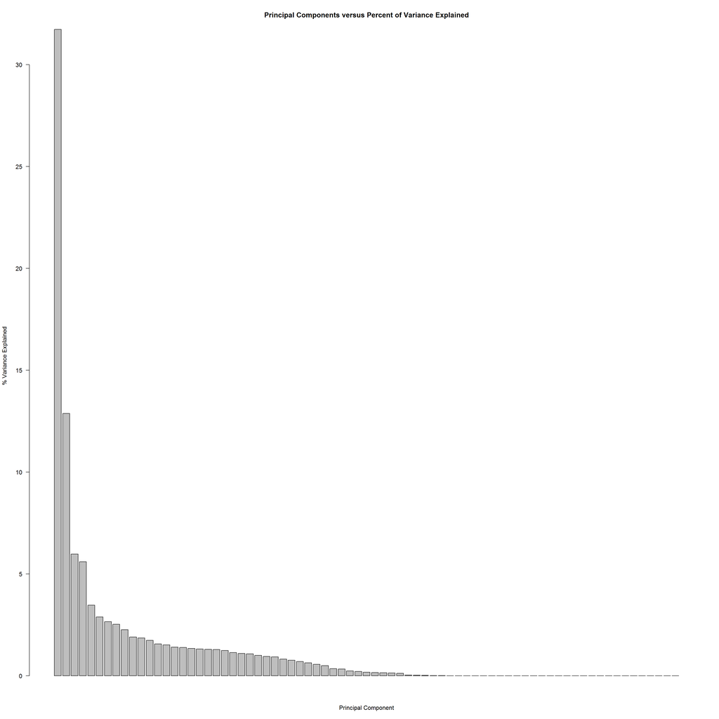

```r
## plot percentage of variance explained for each principal component
barplot(p.variance.explained, las=2, xlab="Principal Component", ylab="% Variance Explained", main="Principal Components versus Percent of Variance Explained")
```

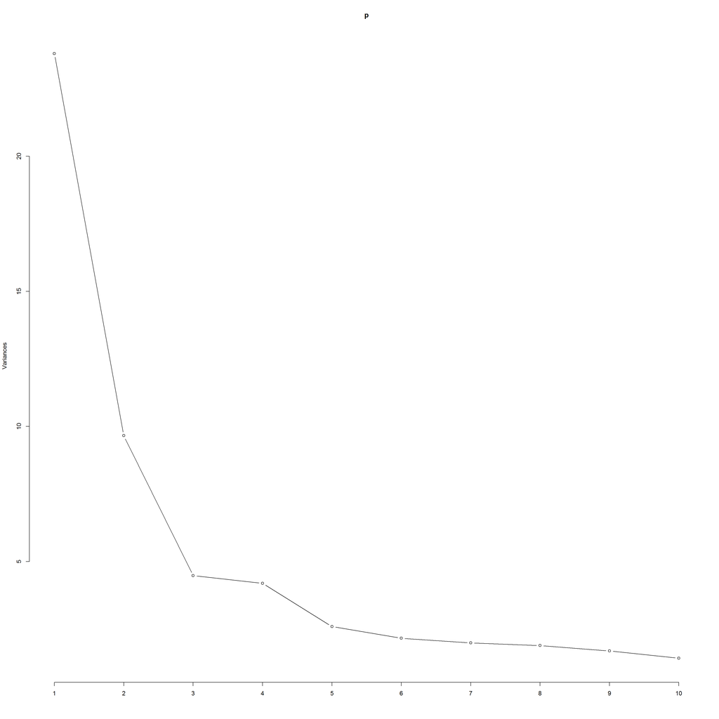

```r
screeplot(p,type="line")
```

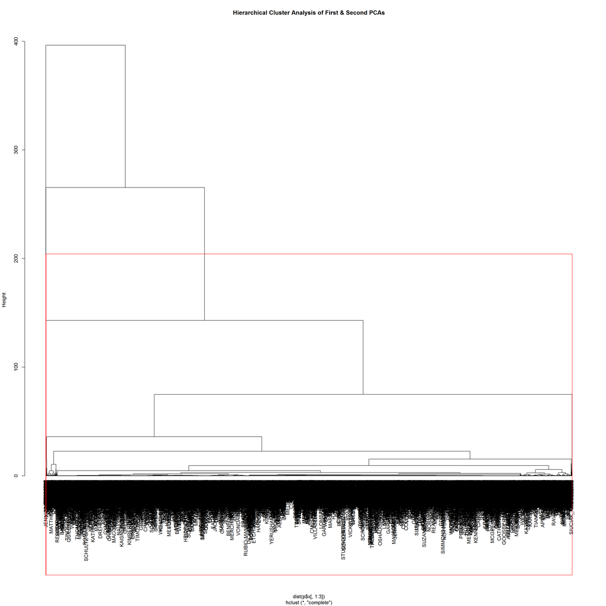

```r
hc_tree<-hclust(dist(p$x[,1:3]), method="complete") # 1:3 = based on 3 components

#plot(hc_tree)
groups <- cutree(hc_tree, k=3)

plot(hc_tree, hang = -1, main= "Hierarchical Cluster Analysis of First & Second PCAs")
rect.hclust(hc_tree, k=3, border="red")
```

```r
userTimerSparse_df$clusterP<-groups #writing out the cluster assignment for each users

table(userTimerSparse_df$clusterP)
```

```
##
##     1     2     3
## 11370     4     1
```

#### PCA Cluster profiles:

- Group 1 (11,370) General users
- Group 2 (4) Three Engineers one test Engineer
- Group 3 (1) Another Engineer on our team (Anchorman of the movie dataset)

Who is in group 2 and group 3

```r
groups[which(groups == 2)]
```

```
## EA026644 MI015732 NN015626 SS021512
##        2        2        2        2
```

```r
groups[which(groups == 3)]
```

```
## MV026119
##        3
```

```r
#kable(userTimerSparse_df["MV026119",])
```

## Supervised Learning

So far I tried all three unsupervised learning methods. Next I want to use supervised learning method to classify slowness defined as greater than one seconds. First I want to use decision tree on data set. Next I create dummy variables from decision tree, and convert date time to a number of seconds from begin date time for logistic regression model. Next I used Naïve Bayes to fit the data set.

```r
# CAP timer does not have track time
userTimerNames <- timerNames[grepl("USR*|ENG*", timerNames)]
#userTimerNames

usr_timer <- timer[which(timer$TIMERNAME %in% userTimerNames),]
dim(usr_timer)
```

```
## [1] 628078     23
```

```r
#unique(usr_timer$TIMERNAME)
summary(usr_timer)
```

```
##      CLIENT           DOMAIN                ENTERPRISE
##  TRIN_MI: 73806   PROD   : 64833   AHS_FL        : 70794
##  AHS_FL : 70794   P149E  : 48688   MAIN_PROD_CTX : 40338
##  FLHO_FL: 36019   P1751  : 35901   FLHO_FL       : 36019
##  MCGH_GA: 31242   A1PRD  : 31661   ALPHA_PROD_CTX: 31661
##  LAC_CA : 25143   P461   : 31229   MCGH_GA       : 31242
##  AHSW_CA: 23166   P0278  : 25138   PROD          : 26289
##  (Other):367908   (Other):390628   (Other)       :391735
##   ELAPSEDTIME
##  Min.   :  0.00000
##  1st Qu.:  0.09748
##  Median :  0.13697
##  Mean   :  0.31380
##  3rd Qu.:  0.21064
##  Max.   :198.85646
##
##                                                        TIMERNAME
##  USR:MPG.RCM.UTILIZATION_MANAGEMENT - LOAD COMPONENT        :454991
##  USR:MPG.RCM.DISCHARGEREVIEWWORKLIST - GET ORDER DETAILS    : 52845
##  USR:MPG.RCM.UTILIZATIONREVIEWWORKLIST - GET ORDER DETAILS  : 39548
##  USR:MPG.RCM.CLINICAL_REVIEW - MODIFY MANUAL CLINICAL REVIEW: 28109
##  USR:MPG.RCM.CLINICAL_REVIEW - ADD INTERQUAL CLINICAL REVIEW: 18216
##  USR:MPG.RCM.CLINICAL_REVIEW - SEND CLINICAL FAX            :  8329
##  (Other)                                                    : 26040
##                            PROPERTYVALUES   FRAMEWORKVERSION
##                                   :617936   Min.   :3.000
##  POST-ACUTE PLACEMENT             :  3877   1st Qu.:4.000
##  POST-ACUTE SERVICES              :  1676   Median :4.000
##  ,LOAD PROVIDER RESULTS           :  1655   Mean   :3.999
##  VB_CMONLYEDITORS,                :   372   3rd Qu.:4.000
##  VB_CMONLYEDITORS,RENDER COMPONENT:   357   Max.   :4.000
##  (Other)                          :  2205
##                ENDDATETIME              CLIENTIP       USERPRINCIPALS
##  17-Apr-2017 05:47:34:    33   0.0.0.0      : 27380   YUMULD1 :  1070
##  17-Apr-2017 05:51:45:    33   10.7.131.136 :  1226   004958  :   979
##  18-Apr-2017 10:00:23:    32   10.6.26.93   :  1096   RWDOTY  :   957
##  18-Apr-2017 06:58:45:    31   10.250.10.125:  1085   MLCRUM  :   950
##  18-Apr-2017 07:58:22:    29   10.15.17.172 :  1070   APITTMAN:   935
##  18-Apr-2017 13:16:59:    29   10.4.2.86    :   966   AFPMOORE:   927
##  (Other)             :627891   (Other)      :595255   (Other) :622260
```

[output cut: 41 more lines]

```
##  Min.   :     1268545094   Min.   :     1268780738
##  1st Qu.:  1496006313500   1st Qu.:  1496318960920
##  Median :  4780029576300   Median :  4780382529400
##  Mean   :  7629361010070   Mean   :  7629674807670
##  3rd Qu.: 10953414709000   3rd Qu.: 10953640929400
##  Max.   :570224189987000   Max.   :570224857344000
##
##     TIMER_ID
##  Min.   :2343551258420
##  1st Qu.:2346561383500
##  Median :2347275526210
##  Mean   :2347586553870
##  3rd Qu.:2349369166060
##  Max.   :2352625501940
##
```

```r
#remove duplicate data and unrelatd info to speed
usr_timer$METADATA1 = NULL
usr_timer$METADATA2 = NULL
usr_timer$METADATA3 = NULL
usr_timer$FRAMEWORKVERSION = NULL
usr_timer$PROPERTYVALUES = NULL
usr_timer$START_OFFSET = NULL
usr_timer$START_OFFSET = NULL
usr_timer$STOP_OFFSET = NULL
usr_timer$THREADID = NULL
usr_timer$RESULTCOUNT = NULL
#duplicate data timer_ID is like timer name
usr_timer$TIMER_ID = NULL
usr_timer$VERSION = NULL
usr_timer$ENTERPRISE = NULL
#client is like domain
usr_timer$CLIENT = NULL
usr_timer$CLIENTNAME = NULL
usr_timer$CLIENTIP = NULL
usr_timer$NODEIP = NULL
# user cluster results to create dummy variables
usr_timer$userGroup1 = ifelse(usr_timer$USERPRINCIPALS %in% userGroup1$user,1,0)
usr_timer$userGroup2 = ifelse(usr_timer$USERPRINCIPALS %in% userGroup2$user,1,0)
usr_timer$userGroup3 = ifelse(usr_timer$USERPRINCIPALS %in% userGroup3$user,1,0)
usr_timer$USERPRINCIPALS = NULL
usr_timer$PROCESSID <- as.numeric(usr_timer$PROCESSID)
```

```r
set.seed(123)
## run out of memory with larger data, sample 10000 rows
usr_timer <- usr_timer[sample(1:nrow(usr_timer), 10000, replace=FALSE),]

usr_timer_avg <- aggregate(data = usr_timer, ELAPSEDTIME ~ TIMERNAME, mean, na.rm = TRUE)
usr_timer_avg <- usr_timer_avg[order(-usr_timer_avg$ELAPSEDTIME), ]
#usr_timer_avg

usr_timer$SLOWNESS <- ifelse(usr_timer$ELAPSEDTIME>1,'yes','no')
usr_timer$SLOWNESS <- as.factor(usr_timer$SLOWNESS)
summary(usr_timer$SLOWNESS)
```

```
##   no  yes
## 9648  352
```

```r
usr_timer$ELAPSEDTIME <- NULL

# convert date time to numeric number of minutes from first day
usr_timer$dateTime <- strptime(usr_timer$ENDDATETIME, "%d-%b-%Y %H:%M:%S")
usr_timer$DAY <- as.numeric(format(as.Date(usr_timer$ENDDATETIME,format="%d-%b-%Y"), "%d"))
usr_timer$EXECUTETIME <- (usr_timer$DAY - 16) * 1440 + hour(usr_timer$dateTime) * 60 + minute(usr_timer$dateTime)
usr_timer$DAY <- NULL
usr_timer$dateTime <- NULL
usr_timer$ENDDATETIME <- NULL
```

Use caret to split training and validation sets.

```r
set.seed(123)
trainIndex <- createDataPartition(usr_timer$SLOWNESS, p = .8,list = FALSE, times = 1)
timer_train <- usr_timer[ trainIndex,]
timer_validate <- usr_timer[ -trainIndex,]
```

Use reusable function to print accuracy result.

```r
getResult<- function(myModel, predictType, testData)
{
  actual <- testData$SLOWNESS
  predicted <- predict(myModel, testData, type=predictType)
  results.matrix <- confusionMatrix(predicted, actual, positive="yes")
  print(results.matrix)
}
```

### RPart decision tree

```r
set.seed(123)
timer_rpart <- rpart(timer_train$SLOWNESS~., method="class", parms = list(split="gini"), data=timer_train)
#plot(as.party(timer_rpart))

getResult(timer_rpart, "class", timer_validate)
```

```
## Confusion Matrix and Statistics
##
##           Reference
## Prediction   no  yes
##        no  1896   49
##        yes   33   21
##
##                Accuracy : 0.959
##                  95% CI : (0.9493, 0.9672)
##     No Information Rate : 0.965
##     P-Value [Acc > NIR] : 0.93301
##
##                   Kappa : 0.3179
##  Mcnemar's Test P-Value : 0.09763
##
##             Sensitivity : 0.30000
##             Specificity : 0.98289
##          Pos Pred Value : 0.38889
##          Neg Pred Value : 0.97481
##              Prevalence : 0.03502
##          Detection Rate : 0.01051
##    Detection Prevalence : 0.02701
##       Balanced Accuracy : 0.64145
##
##        'Positive' Class : yes
##
```

```r
cptable<-printcp(timer_rpart)
```

```
##
## Classification tree:
## rpart(formula = timer_train$SLOWNESS ~ ., data = timer_train,
##     method = "class", parms = list(split = "gini"))
##
## Variables actually used in tree construction:
## [1] NODENAME  TIMERNAME
##
## Root node error: 282/8001 = 0.035246
##
## n= 8001
##
##         CP nsplit rel error  xerror     xstd
## 1 0.255319      0   1.00000 1.00000 0.058490
## 2 0.026596      2   0.48936 0.87589 0.054864
## 3 0.010000      5   0.40780 1.02482 0.059185
```

```r
cptable
```

```
##           CP nsplit rel error    xerror       xstd
## 1 0.25531915      0 1.0000000 1.0000000 0.05849030
## 2 0.02659574      2 0.4893617 0.8758865 0.05486434
## 3 0.01000000      5 0.4078014 1.0248227 0.05918494
```

```r
set.cp.value<-cptable[which.min(cptable[,"xerror"]),"CP"]
pruned_timer_rpart <- prune(timer_rpart, cp=set.cp.value)
getResult(pruned_timer_rpart, "class", timer_validate)
```

```
## Confusion Matrix and Statistics
##
##           Reference
## Prediction   no  yes
##        no  1911   51
##        yes   18   19
##
##                Accuracy : 0.9655
##                  95% CI : (0.9565, 0.973)
##     No Information Rate : 0.965
##     P-Value [Acc > NIR] : 0.483253
##
##                   Kappa : 0.3391
##  Mcnemar's Test P-Value : 0.000117
##
##             Sensitivity : 0.271429
##             Specificity : 0.990669
##          Pos Pred Value : 0.513514
##          Neg Pred Value : 0.974006
##              Prevalence : 0.035018
##          Detection Rate : 0.009505
##    Detection Prevalence : 0.018509
##       Balanced Accuracy : 0.631049
##
##        'Positive' Class : yes
##
```

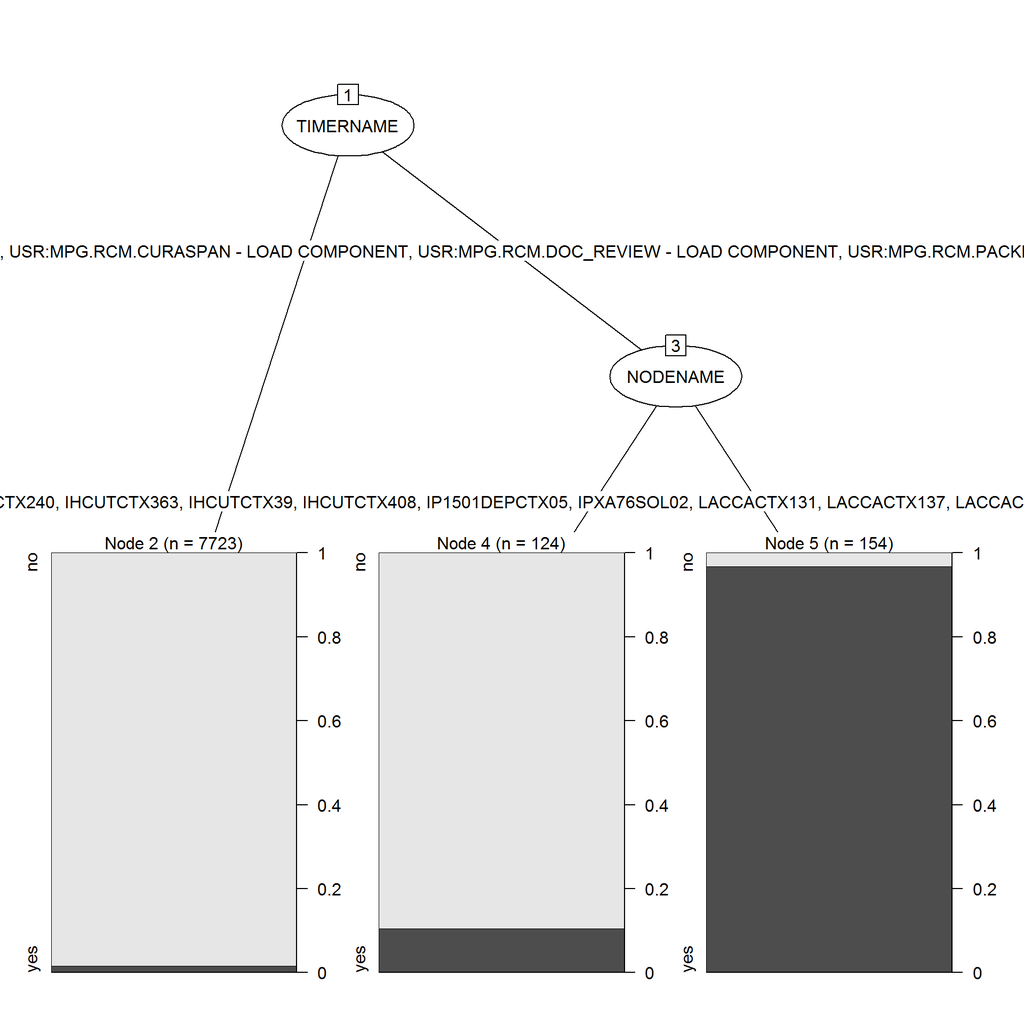

```r
plot(as.party(pruned_timer_rpart))
```

#### 10-fold cross validation

```r
fitControl <- trainControl(method="cv", number=10)
set.seed(123)
timer_10folds<-train(SLOWNESS~., data=timer_train, method="rpart", metric="Accuracy", trControl=fitControl)
#plot(as.party(timer_10folds$finalModel))
getResult(timer_10folds, "raw", timer_validate)
```

```
## Confusion Matrix and Statistics
##
##           Reference
## Prediction   no  yes
##        no  1892   37
##        yes   37   33
##
##                Accuracy : 0.963
##                  95% CI : (0.9537, 0.9708)
##     No Information Rate : 0.965
##     P-Value [Acc > NIR] : 0.7125
##
##                   Kappa : 0.4522
##  Mcnemar's Test P-Value : 1.0000
##
##             Sensitivity : 0.47143
##             Specificity : 0.98082
##          Pos Pred Value : 0.47143
##          Neg Pred Value : 0.98082
##              Prevalence : 0.03502
##          Detection Rate : 0.01651
##    Detection Prevalence : 0.03502
##       Balanced Accuracy : 0.72612
##
##        'Positive' Class : yes
##
```

```r
cptable<-printcp(timer_rpart)
```

```
##
## Classification tree:
## rpart(formula = timer_train$SLOWNESS ~ ., data = timer_train,
##     method = "class", parms = list(split = "gini"))
##
## Variables actually used in tree construction:
## [1] NODENAME  TIMERNAME
##
## Root node error: 282/8001 = 0.035246
##
## n= 8001
##
##         CP nsplit rel error  xerror     xstd
## 1 0.255319      0   1.00000 1.00000 0.058490
## 2 0.026596      2   0.48936 0.87589 0.054864
## 3 0.010000      5   0.40780 1.02482 0.059185
```

```r
cptable
```

```
##           CP nsplit rel error    xerror       xstd
## 1 0.25531915      0 1.0000000 1.0000000 0.05849030
## 2 0.02659574      2 0.4893617 0.8758865 0.05486434
## 3 0.01000000      5 0.4078014 1.0248227 0.05918494
```

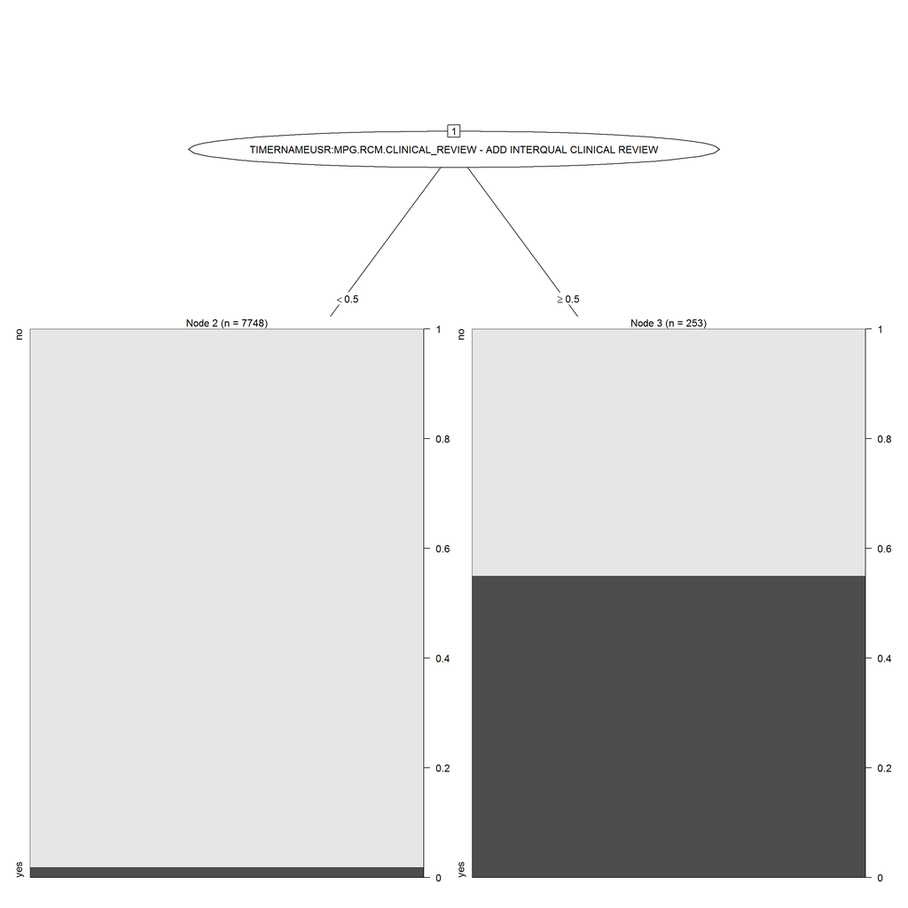

```r
set.cp.value<-cptable[which.min(cptable[,"xerror"]),"CP"]
timer_10folds_pruned<-prune(timer_10folds$finalModel, cp=set.cp.value)
plot(as.party(timer_10folds_pruned))
```

### Naive Bayes

```r
set.seed(123)
timer_nb <- naiveBayes(SLOWNESS~., data=timer_train, laplace = 1)
nbPredicted <- predict(timer_nb, timer_validate)
nbConfusionMatrix <- confusionMatrix(nbPredicted, timer_validate$SLOWNESS, positive="yes")
print(nbConfusionMatrix)
```

```
## Confusion Matrix and Statistics
##
##           Reference
## Prediction   no  yes
##        no  1913   60
##        yes   16   10
##
##                Accuracy : 0.962
##                  95% CI : (0.9526, 0.9699)
##     No Information Rate : 0.965
##     P-Value [Acc > NIR] : 0.7876
##
##                   Kappa : 0.193
##  Mcnemar's Test P-Value : 0.0000008121
##
##             Sensitivity : 0.142857
##             Specificity : 0.991706
##          Pos Pred Value : 0.384615
##          Neg Pred Value : 0.969589
##              Prevalence : 0.035018
##          Detection Rate : 0.005003
##    Detection Prevalence : 0.013007
##       Balanced Accuracy : 0.567281
##
##        'Positive' Class : yes
##
```

```r
# Caret package also supports NB
#timer_nb <- train(SLOWNESS~., data=timer_train, method = "nb", metric="Accuracy")
#plot(as.party(timer_nb$finalModel))
#getResult(timer_treebag, "raw", timer_validate)
```

### Logistic Regression

```r
long_timer <- c("USR:MPG.RCM.CLINICAL_REVIEW - ADD CLINICAL REVIEW ADDENDUMS","USR:MPG.RCM.CLINICAL_REVIEW - ADD MANUAL CLINICAL REVIEW",
                "USR:MPG.RCM.CLINICAL_REVIEW - LOAD INTERQUAL CLINICAL REVIEW","USR:MPG.RCM.CLINICAL_REVIEW - MODIFY MANUAL CLINICAL REVIEW",
                "USR:MPG.RCM.CLINICAL_REVIEW - SEND CLINICAL FAX","USR:MPG.RCM.DISCHARGEREVIEWWORKLIST - GET ORDER DETAILS","USR:MPG.RCM.UTILIZATION_MANAGEMENT - LOAD COMPONENT",
                "USR:MPG.RCM.UTILIZATIONREVIEWWORKLIST - GET ORDER DETAILS")
slow_node <- c("BHSFLCTX32","BHSFLCTX69","EJEFLACTX66","FLHOFLCTX232","IHCUTCTX386","LACCACTX09","UTHDCHSMPCPA014")

timer_train$SLOW_TIMER <- ifelse(timer_train$TIMERNAME %in% long_timer,1,0)
timer_train$SLOW_NODE <- ifelse(timer_train$NODENAME %in% slow_node,1,0)
timer_logit_train <- timer_train[,c(4:12)]

timer_validate$SLOW_TIMER <- ifelse(timer_validate$TIMERNAME %in% long_timer,1,0)
timer_validate$SLOW_NODE <- ifelse(timer_validate$NODENAME %in% slow_node,1,0)
timer_logit_validate <- timer_validate[,c(4:12)]

set.seed(123)
timer_lg <- train(SLOWNESS~., data=timer_logit_train, method="glm", family="binomial")
```

[output not shown]

[output cut: 19 more lines]

[output not shown]

```r
summary(timer_lg)
```

```
##
## Call:
## NULL
##
## Deviance Residuals:
##     Min       1Q   Median       3Q      Max
## -1.1872  -0.1876  -0.1804  -0.1602   3.0573
##
## Coefficients: (1 not defined because of singularities)
##                                Estimate    Std. Error z value
## (Intercept)                 0.041484517   1.253791566   0.033
## APPLICATIONNAMEFIRSTNET    -0.246372454   1.323980056  -0.186
## APPLICATIONNAMEPOWERCHART   0.087076511   1.232952216   0.071
## APPLICATIONNAMESNSURGINET  -8.393855693 324.746070021  -0.026
## APPLICATIONNAMEUNKNOWN     -1.033028771   1.463664057  -0.706
## PROCESSID                   0.000001787   0.000016224   0.110
## userGroup1                 -0.381112625   0.459895228  -0.829
## userGroup2                 -0.298159294   0.200806083  -1.485
## userGroup3                           NA            NA      NA
## EXECUTETIME                -0.000212640   0.000076328  -2.786
## SLOW_TIMER                 -3.735719562   0.139423883 -26.794
## SLOW_NODE                  -0.166708182   1.135734550  -0.147
##                                       Pr(>|z|)
## (Intercept)                            0.97361
## APPLICATIONNAMEFIRSTNET                0.85238
## APPLICATIONNAMEPOWERCHART              0.94370
## APPLICATIONNAMESNSURGINET              0.97938
## APPLICATIONNAMEUNKNOWN                 0.48032
## PROCESSID                              0.91229
## userGroup1                             0.40728
## userGroup2                             0.13759
## userGroup3                                  NA
## EXECUTETIME                            0.00534 **
## SLOW_TIMER                < 0.0000000000000002 ***
## SLOW_NODE                              0.88330
## ---
## Signif. codes:  0 '***' 0.001 '**' 0.01 '*' 0.05 '.' 0.1 ' ' 1
##
## (Dispersion parameter for binomial family taken to be 1)
##
##     Null deviance: 2440.8  on 8000  degrees of freedom
## Residual deviance: 1768.7  on 7990  degrees of freedom
## AIC: 1790.7
##
## Number of Fisher Scoring iterations: 11
```

```r
getResult(timer_lg, "raw", timer_logit_validate)
```

```
## Confusion Matrix and Statistics
##
##           Reference
## Prediction   no  yes
##        no  1927   68
##        yes    2    2
##
##                Accuracy : 0.965
##                  95% CI : (0.956, 0.9726)
##     No Information Rate : 0.965
##     P-Value [Acc > NIR] : 0.5317
##
##                   Kappa : 0.0505
##  Mcnemar's Test P-Value : 0.000000000000007912
##
##             Sensitivity : 0.028571
##             Specificity : 0.998963
##          Pos Pred Value : 0.500000
##          Neg Pred Value : 0.965915
##              Prevalence : 0.035018
##          Detection Rate : 0.001001
##    Detection Prevalence : 0.002001
##       Balanced Accuracy : 0.513767
##
##        'Positive' Class : yes
##
```

### Random Forest

```r
timer_RForest <- randomForest(SLOWNESS~., data=timer_logit_train, mtry=3, ntree=500, na.action = na.omit, importance=TRUE)
print(timer_RForest)
```

```
##
## Call:
##  randomForest(formula = SLOWNESS ~ ., data = timer_logit_train,      mtry = 3, ntree = 500, importance = TRUE, na.action = na.omit)
##                Type of random forest: classification
##                      Number of trees: 500
## No. of variables tried at each split: 3
##
##         OOB estimate of  error rate: 3.47%
## Confusion matrix:
##       no yes class.error
## no  7703  16 0.002072807
## yes  262  20 0.929078014
```

```r
importance(timer_RForest)
```

```
##                         no        yes MeanDecreaseAccuracy
## APPLICATIONNAME  5.2953755  7.3072257           8.13782677
## PROCESSID        8.0614847  0.1670255           7.37733801
## userGroup1       0.9940112 -2.4463322           0.04912537
## userGroup2       5.7274056 -0.5695454           5.39199606
## userGroup3       5.8896143 -4.1878272           3.95692976
## EXECUTETIME      8.2874109  4.9676870           9.93153823
## SLOW_TIMER      31.9491101 38.4783188          37.24682872
## SLOW_NODE        1.3201993  0.7937402           1.44734379
##                 MeanDecreaseGini
## APPLICATIONNAME        4.3177278
## PROCESSID             66.4761095
## userGroup1             1.2784161
## userGroup2             2.7938566
## userGroup3             3.3464411
## EXECUTETIME           62.4625261
## SLOW_TIMER           110.7997710
## SLOW_NODE              0.6193148
```

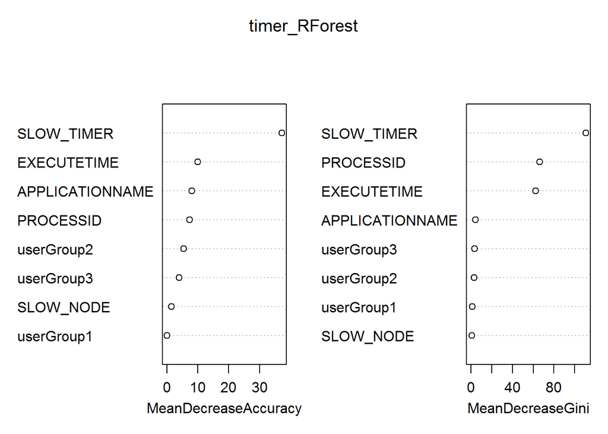

```r
varImpPlot(timer_RForest)
```

```r
getResult(timer_RForest, "class", timer_logit_validate)
```

```
## Confusion Matrix and Statistics
##
##           Reference
## Prediction   no  yes
##        no  1924   67
##        yes    5    3
##
##                Accuracy : 0.964
##                  95% CI : (0.9549, 0.9717)
##     No Information Rate : 0.965
##     P-Value [Acc > NIR] : 0.626
##
##                   Kappa : 0.0702
##  Mcnemar's Test P-Value : 0.0000000000006531
##
##             Sensitivity : 0.042857
##             Specificity : 0.997408
##          Pos Pred Value : 0.375000
##          Neg Pred Value : 0.966349
##              Prevalence : 0.035018
##          Detection Rate : 0.001501
##    Detection Prevalence : 0.004002
##       Balanced Accuracy : 0.520133
##
##        'Positive' Class : yes
##
```

### ROC Curves

Here are results of three classification models. Notice the sensitivity are pretty low but overall accuracy is high. This is because most of timers are within 1 seconds. So it is harder to predict those small percentage of timers that are greater than 1 seconds. Kappa ratio shows Decision Tree is a OK model.

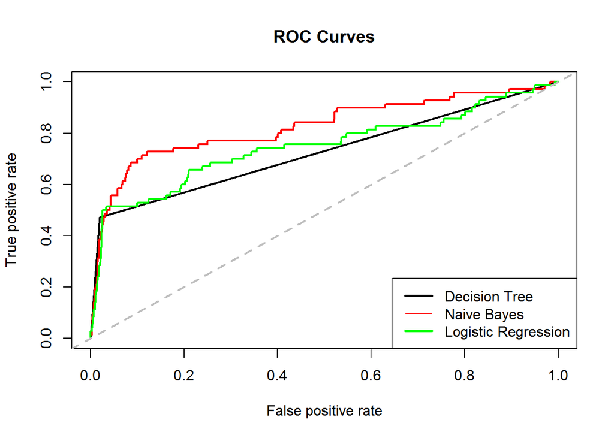

```r
#ROC
#Create a ROC curve
library(ROCR)

R10Fold_predict_prob<-predict(timer_10folds, type="prob", timer_validate)
R10Fold_pred = prediction(R10Fold_predict_prob[,2], timer_validate$SLOWNESS)
R10Fold_perf = performance(R10Fold_pred,"tpr", "fpr") #true pos and false pos

nb_predict_prob<-predict(timer_nb, type="raw", timer_validate)
nb_pred = prediction(nb_predict_prob[,2], timer_validate$SLOWNESS)
nb_perf = performance(nb_pred,"tpr", "fpr") #true pos and false pos

logit_predict_prob<-predict(timer_lg, type="prob", timer_validate)
logit_pred = prediction(logit_predict_prob[,2], timer_validate$SLOWNESS)
logit_perf = performance(logit_pred,"tpr", "fpr") #true pos and false pos


# Start plotting
plot(R10Fold_perf, main="ROC Curves", col="black", lwd=2)
plot(nb_perf, add=TRUE, col="red", lwd=2)
plot(logit_perf, add=TRUE, col="green", lwd=2)
abline(a=0, b=1, lwd=2, lty=2, col="gray")
legend('bottomright', c("Decision Tree", "Naive Bayes", "Logistic Regression"),
       lty=c(1,1), lwd=c(2.5,1), col=c("black","red","green"))
```

## Summary

- We can clearly see three groups of clustering users (general users, discharge nurses, utilization review nurses). PCA divides user further to regular users vs engineers and testers.
- Apriori on user transaction data gives us typical user workflows with high confidence and lift (strong rules).
- Particular timers, executing time can cause slowness. Classification models has high Accuracy rate but low Sensitivity rate. Picking the threshold of 1 seconds for slowness is arbitrary.

END